# MultiNicheNet analysis: anti-PD1 Breast cancer multifactorial comparison

## 1.3 Prepare the settings of the MultiNicheNet cell-cell communication analysis

In this step, we will formalize our research question into MultiNicheNet input arguments.

In this case study, we want to study differences in therapy-induced cell-cell communication changes (On-vs-Pre therapy) between two patient groups (E vs NE: patients with clonotype expansion versus patients without clonotype expansion). Both therapy-timepoint and patient group are indicated in the following meta data column: `expansion_timepoint`, which has 4 different values: PreE, PreNE, OnE, OnNE.

Cell type annotations are indicated in the `subType` column, and the sample is indicated by the `sample_id` column.

```r
sample_id = "sample_id"
group_id = "expansion_timepoint"
celltype_id = "subType"
```

**Important**: It is required that each sample-id is uniquely assigned to only one condition/group of interest. Therefore, our `sample_id` here does not only indicate the patient, but also the timepoint of sampling.

If you would have batch effects or covariates you can correct for, you can define this here as well. However, this is not applicable to this dataset. Therefore we will use the following NA settings:

```r
batches = NA
covariates = NA
```

**Important**: for batches, there should be at least one sample for every group-batch combination. If one of your groups/conditions lacks a certain level of your batch, you won’t be able to correct for the batch effect because the model is then not able to distinguish batch from group/condition effects.

**Important**: The column names of group, sample, cell type, and batches should be syntactically valid (`make.names`)

**Important**: All group, sample, cell type, and batch names should be syntactically valid as well (`make.names`) (eg through `SummarizedExperiment::colData(sce)$ShortID = SummarizedExperiment::colData(sce)$ShortID %>% make.names()`)

If you want to focus the analysis on specific cell types (e.g. because you know which cell types reside in the same microenvironments based on spatial data), you can define this here. If you have sufficient computational resources and no specific idea of cell-type colocalzations, we recommend to consider all cell types as potential senders and receivers.

Here we will consider all cell types in the data:

```r
senders_oi = SummarizedExperiment::colData(sce)[,celltype_id] %>% unique()
receivers_oi = SummarizedExperiment::colData(sce)[,celltype_id] %>% unique()
sce = sce[, SummarizedExperiment::colData(sce)[,celltype_id] %in%
            c(senders_oi, receivers_oi)
          ]
```

In case you would have samples in your data that do not belong to one of the groups/conditions of interest, we recommend removing them and only keeping conditions of interest.

Before we do this, we will here rename our group/timepoint combinations. This is not necessary for you to do this, but then you will need to replace “G1.T1” with the equivalent of group1-timepoint1 in your data. Etc.

```r
SummarizedExperiment::colData(sce)[,group_id][SummarizedExperiment::colData(sce)[,group_id] == "PreE"] = "G1.T1"
SummarizedExperiment::colData(sce)[,group_id][SummarizedExperiment::colData(sce)[,group_id] == "PreNE"] = "G2.T1"
SummarizedExperiment::colData(sce)[,group_id][SummarizedExperiment::colData(sce)[,group_id] == "OnE"] = "G1.T2"
SummarizedExperiment::colData(sce)[,group_id][SummarizedExperiment::colData(sce)[,group_id] == "OnNE"] = "G2.T2"
```

```r
conditions_keep = c("G1.T1", "G2.T1", "G1.T2", "G2.T2")
sce = sce[, SummarizedExperiment::colData(sce)[,group_id] %in%
            conditions_keep
          ]
```

## 1.4 Defining the parameters of the MultiNicheNet core analyses

In MultiNicheNet, following steps are executed:

- 1. Cell-type filtering: determine which cell types are sufficiently present
- 2. Gene filtering: determine which genes are sufficiently expressed in each present cell type
- 3. Pseudobulk expression calculation: determine and normalize per-sample pseudobulk expression levels for each expressed gene in each present cell type
- 4. Differential expression (DE) analysis: determine which genes are differentially expressed
- 5. Ligand activity prediction: use the DE analysis output to predict the activity of ligands in receiver cell types and infer their potential target genes
- 6. Prioritization: rank cell-cell communication patterns through multi-criteria prioritization

For each of these steps, some parameters need to be defined. This is what we will do now.

*Parameters for step 1: Cell-type filtering:*

Since MultiNicheNet will infer group differences at the sample level for each cell type (currently via Muscat - pseudobulking + EdgeR), we need to have sufficient cells per sample of a cell type, and this for all groups. In the following analysis we will set this minimum number of cells per cell type per sample at 10. Samples that have less than `min_cells` cells will be excluded from the analysis for that specific cell type.

```r
min_cells = 10
```

*Parameters for step 2: Gene filtering*

For each cell type, we will consider genes expressed if they are expressed in at least a `min_sample_prop` fraction of samples in the condition with the lowest number of samples. By default, we set `min_sample_prop = 0.50`.

```r
min_sample_prop = 0.50
```

But how do we define which genes are expressed in a sample? For this we will consider genes as expressed if they have non-zero expression values in a `fraction_cutoff` fraction of cells of that cell type in that sample. By default, we set `fraction_cutoff = 0.05`, which means that genes should show non-zero expression values in at least 5% of cells in a sample.

```r
fraction_cutoff = 0.05
```

*Parameters for step 5: Ligand activity prediction*

One of the prioritization criteria is the predicted activity of ligands in receiver cell types. Similarly to base NicheNet (https://github.com/saeyslab/nichenetr), we use the DE output to create a “geneset of interest”: here we assume that DE genes within a cell type may be DE because of differential cell-cell communication processes. To determine the genesets of interest based on DE output, we need to define which logFC and/or p-value thresholds we will use.

By default, we will apply the p-value cutoff on the normal p-values, and not on the p-values corrected for multiple testing. This choice was made because most multi-sample single-cell transcriptomics datasets have just a few samples per group and we might have a lack of statistical power due to pseudobulking. But, if the smallest group >= 20 samples, we typically recommend using p_val_adj = TRUE. When the biological difference between the conditions is very large, we typically recommend increasing the logFC_threshold and/or using p_val_adj = TRUE.

```r
logFC_threshold = 0.50
p_val_threshold = 0.05
```

```r
p_val_adj = FALSE
```

After the ligand activity prediction, we will also infer the predicted target genes of these ligands in each contrast. For this ligand-target inference procedure, we also need to select which top n of the predicted target genes will be considered (here: top 250 targets per ligand). This parameter will not affect the ligand activity predictions. It will only affect ligand-target visualizations and construction of the intercellular regulatory network during the downstream analysis. We recommend users to test other settings in case they would be interested in exploring fewer, but more confident target genes, or vice versa.

```r
top_n_target = 250
```

The NicheNet ligand activity analysis can be run in parallel for each receiver cell type, by changing the number of cores as defined here. Using more cores will speed up the analysis at the cost of needing more memory. This is only recommended if you have many receiver cell types of interest. You can define here the maximum number of cores you want to be used.

```r
n.cores = 8
```

*Parameters for step 6: Prioritization*

We will use the following criteria to prioritize ligand-receptor interactions:

- Upregulation of the ligand in a sender cell type and/or upregulation of the receptor in a receiver cell type - in the condition of interest.
- Cell-type specific expression of the ligand in the sender cell type and receptor in the receiver cell type in the condition of interest (to mitigate the influence of upregulated but still relatively weakly expressed ligands/receptors).
- Sufficiently high expression levels of ligand and receptor in many samples of the same group.
- High NicheNet ligand activity, to further prioritize ligand-receptor pairs based on their predicted effect of the ligand-receptor interaction on the gene expression in the receiver cell type.

We will combine these prioritization criteria in a single aggregated prioritization score. In the default setting, we will weigh each of these criteria equally (`scenario = "regular"`). This setting is strongly recommended. However, we also provide some additional setting to accomodate different biological scenarios. The setting `scenario = "lower_DE"` halves the weight for DE criteria and doubles the weight for ligand activity. This is recommended in case your hypothesis is that the differential CCC patterns in your data are less likely to be driven by DE (eg in cases of differential migration into a niche). The setting `scenario = "no_frac_LR_expr"` ignores the criterion “Sufficiently high expression levels of ligand and receptor in many samples of the same group”. This may be interesting for users that have data with a limited number of samples and don’t want to penalize interactions if they are not sufficiently expressed in some samples.

Here we will choose for the regular setting.

```r
scenario = "regular"
```

Finally, we still need to make one choice. For NicheNet ligand activity we can choose to prioritize ligands that only induce upregulation of target genes (`ligand_activity_down = FALSE`) or can lead potentially lead to both up- and downregulation (`ligand_activity_down = TRUE`). The benefit of `ligand_activity_down = FALSE` is ease of interpretability: prioritized ligand-receptor pairs will be upregulated in the condition of interest, just like their target genes. `ligand_activity_down = TRUE` can be harder to interpret because target genes of some interactions may be upregulated in the other conditions compared to the condition of interest. This is harder to interpret, but may help to pick up interactions that can also repress gene expression.

Here we will choose for setting `ligand_activity_down = FALSE` and focus specifically on upregulating ligands.

```r
ligand_activity_down = FALSE
```

# 2 Running the MultiNicheNet core analyses

## 2.1 1) G1.T2-G1.T1: Anti-PD1 therapy associated cell-cell communication changes in patients with clonotype expansion (E)

*Set the required contrast of interest.*

Here, we want to compare on-treatment samples with pre-treatment samples for group E. Therefore we can set this contrast as:

```r
contrasts_oi = c("'G1.T2-G1.T1','G1.T1-G1.T2'")
```

**Very Important** Note the format to indicate the contrasts! This formatting should be adhered to very strictly, and white spaces are not allowed! Check `?get_DE_info` for explanation about how to define this well. The most important points are that: *each contrast is surrounded by single quotation marks* contrasts are separated by a comma without any white space *all contrasts together are surrounded by double quotation marks.

For downstream visualizations and linking contrasts to their main condition, we also need to run the following: This is necessary because we will also calculate cell-type+condition specificity of ligands and receptors.

```r
contrast_tbl = tibble(
  contrast = c("G1.T2-G1.T1", "G1.T1-G1.T2"),
  group = c("G1.T2","G1.T1")
  )
```

### 2.1.1 Run the analysis

*Cell-type filtering: determine which cell types are sufficiently present*

```r
abundance_info = get_abundance_info(
  sce = sce,
  sample_id = sample_id, group_id = group_id, celltype_id = celltype_id,
  min_cells = min_cells,
  senders_oi = senders_oi, receivers_oi = receivers_oi,
  batches = batches
  )
```

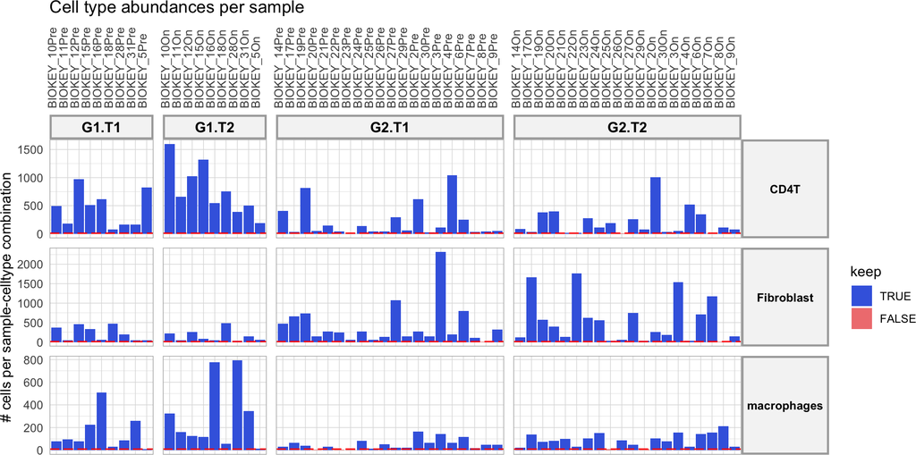

```r
abundance_info$abund_plot_sample
```

*Gene filtering: determine which genes are sufficiently expressed in each present cell type*

```r
frq_list = get_frac_exprs(
  sce = sce,
  sample_id = sample_id, celltype_id =  celltype_id, group_id = group_id,
  batches = batches,
  min_cells = min_cells,
  fraction_cutoff = fraction_cutoff, min_sample_prop = min_sample_prop)
## [1] "Samples are considered if they have more than 10 cells of the cell type of interest"
## [1] "Genes with non-zero counts in at least 5% of cells of a cell type of interest in a particular sample will be considered as expressed in that sample."
## [1] "Genes expressed in at least 4.5 samples will considered as expressed in the cell type: CD4T"
## [1] "Genes expressed in at least 4.5 samples will considered as expressed in the cell type: Fibroblast"
## [1] "Genes expressed in at least 4.5 samples will considered as expressed in the cell type: macrophages"
## [1] "8701 genes are considered as expressed in the cell type: CD4T"
## [1] "10255 genes are considered as expressed in the cell type: Fibroblast"
## [1] "9833 genes are considered as expressed in the cell type: macrophages"
```

Now only keep genes that are expressed by at least one cell type:

```r
genes_oi = frq_list$expressed_df %>%
  filter(expressed == TRUE) %>% pull(gene) %>% unique()
sce = sce[genes_oi, ]
```

*Pseudobulk expression calculation: determine and normalize per-sample pseudobulk expression levels for each expressed gene in each present cell type*

```r
abundance_expression_info = process_abundance_expression_info(
  sce = sce,
  sample_id = sample_id, group_id = group_id, celltype_id = celltype_id,
  min_cells = min_cells,
  senders_oi = senders_oi, receivers_oi = receivers_oi,
  lr_network = lr_network,
  batches = batches,
  frq_list = frq_list,
  abundance_info = abundance_info)
```

*Differential expression (DE) analysis: determine which genes are differentially expressed*

```r
DE_info_group1 = get_DE_info(
  sce = sce,
  sample_id = sample_id, group_id = group_id, celltype_id = celltype_id,
  batches = batches, covariates = covariates,
  contrasts_oi = contrasts_oi,
  min_cells = min_cells,
  expressed_df = frq_list$expressed_df)
## [1] "DE analysis is done:"
## [1] "included cell types are:"
## [1] "CD4T"        "Fibroblast"  "macrophages"
```

Check DE output information in table with logFC and p-values for each gene-celltype-contrast:

```r
DE_info_group1$celltype_de$de_output_tidy %>% head()
## # A tibble: 6 × 9
##   gene  cluster_id   logFC logCPM      F p_val p_adj.loc p_adj contrast
##   <chr> <chr>        <dbl>  <dbl>  <dbl> <dbl>     <dbl> <dbl> <chr>
## 1 A1BG  CD4T       -0.188    5.59 0.899  0.347         1     1 G1.T2-G1.T1
## 2 AAAS  CD4T       -0.0684   4.35 0.0979 0.818         1     1 G1.T2-G1.T1
## 3 AAGAB CD4T       -0.0582   5.01 0.118  0.733         1     1 G1.T2-G1.T1
## 4 AAK1  CD4T       -0.109    7.06 0.343  0.56          1     1 G1.T2-G1.T1
## 5 AAMDC CD4T        0.0708   3.73 0.0593 0.808         1     1 G1.T2-G1.T1
## 6 AAMP  CD4T       -0.158    5.82 1.07   0.306         1     1 G1.T2-G1.T1
```

Evaluate the distributions of p-values:

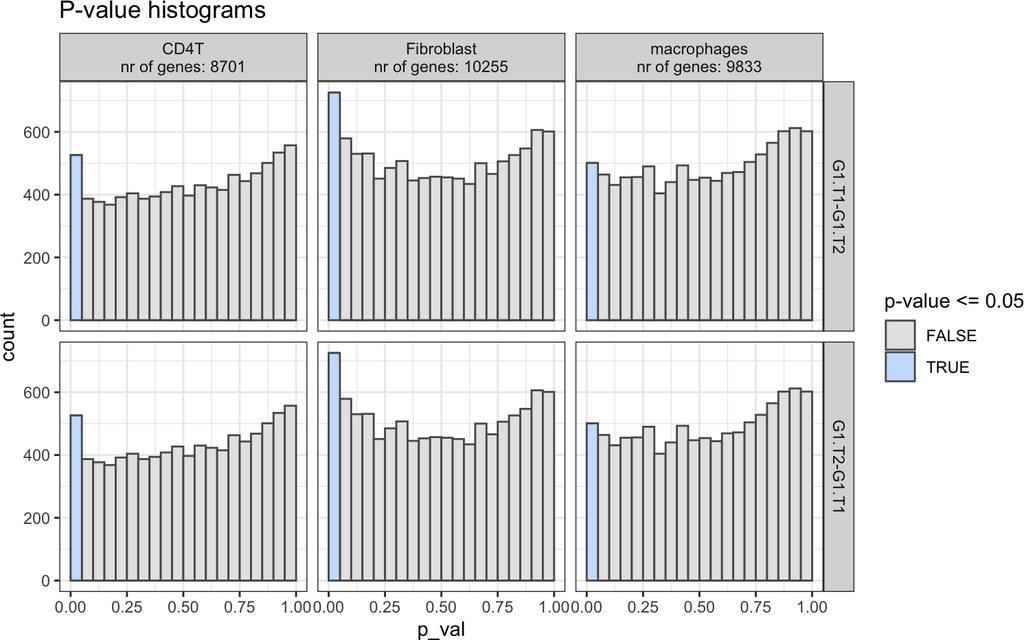

```r
DE_info_group1$hist_pvals
```

These distributions look fine (uniform distribution, except peak at p-value <= 0.05), so we will continue using these regular p-values. In case these p-value distributions look irregular, you can estimate empirical p-values as we will demonstrate in another vignette.

```r
empirical_pval = FALSE
```

```r
if(empirical_pval == TRUE){
  DE_info_emp = get_empirical_pvals(DE_info_group1$celltype_de$de_output_tidy)
  celltype_de_group1 = DE_info_emp$de_output_tidy_emp %>% select(-p_val, -p_adj) %>%
    rename(p_val = p_emp, p_adj = p_adj_emp)
} else {
  celltype_de_group1 = DE_info_group1$celltype_de$de_output_tidy
}
```

*Combine DE information for ligand-senders and receptors-receivers*

```r
sender_receiver_de = combine_sender_receiver_de(
  sender_de = celltype_de_group1,
  receiver_de = celltype_de_group1,
  senders_oi = senders_oi,
  receivers_oi = receivers_oi,
  lr_network = lr_network
)
```

```r
sender_receiver_de %>% head(20)
## # A tibble: 20 × 12
##    contrast    sender      receiver    ligand   receptor lfc_ligand lfc_receptor ligand_receptor_lfc_avg p_val_ligand p_adj_ligand p_val_receptor p_adj_receptor
##    <chr>       <chr>       <chr>       <chr>    <chr>         <dbl>        <dbl>                   <dbl>        <dbl>        <dbl>          <dbl>          <dbl>
##  1 G1.T2-G1.T1 Fibroblast  Fibroblast  SERPINE1 PLAUR          3.23      0.544                      1.89    0.000127        0.0651        0.23             0.895
##  2 G1.T2-G1.T1 Fibroblast  Fibroblast  CCN1     ITGA5          2.3       1.42                       1.86    0.0000031       0.0106        0.00438          0.375
##  3 G1.T1-G1.T2 macrophages macrophages COL1A1   ITGA9          2.12      1.35                       1.74    0.0133          0.814         0.0282           0.938
##  4 G1.T2-G1.T1 Fibroblast  CD4T        SERPINE1 ITGAV          3.23      0.221                      1.73    0.000127        0.0651        0.422            1
##  5 G1.T2-G1.T1 Fibroblast  Fibroblast  SERPINE1 PLAU           3.23      0.204                      1.72    0.000127        0.0651        0.689            1
##  6 G1.T2-G1.T1 Fibroblast  macrophages SERPINE1 ITGAV          3.23      0.168                      1.70    0.000127        0.0651        0.61             1
##  7 G1.T2-G1.T1 Fibroblast  macrophages SERPINE1 LRP1           3.23      0.0928                     1.66    0.000127        0.0651        0.662            1
##  8 G1.T2-G1.T1 Fibroblast  Fibroblast  ANGPTL4  ITGA5          1.86      1.42                       1.64    0.0384          0.664         0.00438          0.375
##  9 G1.T2-G1.T1 macrophages macrophages THBS1    SDC4           2.45      0.791                      1.62    0.0158          0.84          0.0499           0.968
## 10 G1.T1-G1.T2 Fibroblast  Fibroblast  PIP      CD4            2.93      0.307                      1.62    0.129           0.813         0.622            1
## 11 G1.T2-G1.T1 Fibroblast  Fibroblast  SERPINE1 ITGAV          3.23      0.00231                    1.62    0.000127        0.0651        0.991            1
## 12 G1.T2-G1.T1 Fibroblast  CD4T        VEGFA    FLT1           1.89      1.32                       1.60    0.018           0.583         0.00118          0.12
## 13 G1.T2-G1.T1 Fibroblast  Fibroblast  SERPINE1 ITGB5          3.23     -0.0468                     1.59    0.000127        0.0651        0.9              1
## 14 G1.T2-G1.T1 Fibroblast  macrophages SERPINE1 PLAUR          3.23     -0.0975                     1.57    0.000127        0.0651        0.809            1
## 15 G1.T2-G1.T1 Fibroblast  Fibroblast  SERPINE1 PLAT           3.23     -0.109                      1.56    0.000127        0.0651        0.751            1
## 16 G1.T2-G1.T1 Fibroblast  macrophages CCN1     SDC4           2.3       0.791                      1.55    0.0000031       0.0106        0.0499           0.968
## 17 G1.T2-G1.T1 Fibroblast  Fibroblast  SERPINE1 LRP1           3.23     -0.178                      1.53    0.000127        0.0651        0.411            0.97
## 18 G1.T2-G1.T1 Fibroblast  macrophages CCN1     TLR2           2.3       0.739                      1.52    0.0000031       0.0106        0.00337          0.572
## 19 G1.T1-G1.T2 Fibroblast  CD4T        PIP      NPTN           2.93      0.0964                     1.51    0.129           0.813         0.713            1
## 20 G1.T2-G1.T1 macrophages macrophages THBS1    CD47           2.45      0.559                      1.50    0.0158          0.84          0.0269           0.938
```

*Ligand activity prediction: use the DE analysis output to predict the activity of ligands in receiver cell types and infer their potential target genes*

We will first inspect the geneset_oi-vs-background ratios for the default tresholds:

```r
geneset_assessment = contrast_tbl$contrast %>%
  lapply(
    process_geneset_data,
    celltype_de_group1, logFC_threshold, p_val_adj, p_val_threshold
  ) %>%
  bind_rows()
geneset_assessment
## # A tibble: 6 × 12
##   cluster_id  n_background n_geneset_up n_geneset_down prop_geneset_up prop_geneset_down in_range_up in_range_down contrast    logFC_threshold p_val_threshold adjusted
##   <chr>              <int>        <int>          <int>           <dbl>             <dbl> <lgl>       <lgl>         <chr>                 <dbl>           <dbl> <lgl>
## 1 CD4T                8701          206            162          0.0237            0.0186 TRUE        TRUE          G1.T2-G1.T1             0.5            0.05 FALSE
## 2 Fibroblast         10255          265            267          0.0258            0.0260 TRUE        TRUE          G1.T2-G1.T1             0.5            0.05 FALSE
## 3 macrophages         9833          253            196          0.0257            0.0199 TRUE        TRUE          G1.T2-G1.T1             0.5            0.05 FALSE
## 4 CD4T                8701          162            206          0.0186            0.0237 TRUE        TRUE          G1.T1-G1.T2             0.5            0.05 FALSE
## 5 Fibroblast         10255          267            265          0.0260            0.0258 TRUE        TRUE          G1.T1-G1.T2             0.5            0.05 FALSE
## 6 macrophages         9833          196            253          0.0199            0.0257 TRUE        TRUE          G1.T1-G1.T2             0.5            0.05 FALSE
```

We can see here that for all cell type / contrast combinations, all geneset/background ratio’s are within the recommended range (`in_range_up` and `in_range_down` columns). When these geneset/background ratio’s would not be within the recommended ranges, we should interpret ligand activity results for these cell types with more caution, or use different thresholds (for these or all cell types).

```r
ligand_activities_targets_DEgenes = suppressMessages(suppressWarnings(
  get_ligand_activities_targets_DEgenes(
    receiver_de = celltype_de_group1,
    receivers_oi = intersect(receivers_oi, celltype_de_group1$cluster_id %>% unique()),
    ligand_target_matrix = ligand_target_matrix,
    logFC_threshold = logFC_threshold,
    p_val_threshold = p_val_threshold,
    p_val_adj = p_val_adj,
    top_n_target = top_n_target,
    verbose = TRUE,
    n.cores = n.cores
  )
))
```

*Prioritization: rank cell-cell communication patterns through multi-criteria prioritization*

```r
sender_receiver_tbl = sender_receiver_de %>% distinct(sender, receiver)

metadata_combined = SummarizedExperiment::colData(sce) %>% tibble::as_tibble()

if(!is.na(batches)){
  grouping_tbl = metadata_combined[,c(sample_id, group_id, batches)] %>%
    tibble::as_tibble() %>% distinct()
  colnames(grouping_tbl) = c("sample","group",batches)
} else {
  grouping_tbl = metadata_combined[,c(sample_id, group_id)] %>%
    tibble::as_tibble() %>% distinct()
  colnames(grouping_tbl) = c("sample","group")
}

prioritization_tables = suppressMessages(generate_prioritization_tables(
    sender_receiver_info = abundance_expression_info$sender_receiver_info,
    sender_receiver_de = sender_receiver_de,
    ligand_activities_targets_DEgenes = ligand_activities_targets_DEgenes,
    contrast_tbl = contrast_tbl,
    sender_receiver_tbl = sender_receiver_tbl,
    grouping_tbl = grouping_tbl,
    scenario = "regular", # all prioritization criteria will be weighted equally
    fraction_cutoff = fraction_cutoff,
    abundance_data_receiver = abundance_expression_info$abundance_data_receiver,
    abundance_data_sender = abundance_expression_info$abundance_data_sender,
    ligand_activity_down = ligand_activity_down
  ))
```

*Compile the MultiNicheNet output object*

```r
multinichenet_output_group1_t2vst1 = list(
    celltype_info = abundance_expression_info$celltype_info,
    celltype_de = celltype_de_group1,
    sender_receiver_info = abundance_expression_info$sender_receiver_info,
    sender_receiver_de =  sender_receiver_de,
    ligand_activities_targets_DEgenes = ligand_activities_targets_DEgenes,
    prioritization_tables = prioritization_tables,
    grouping_tbl = grouping_tbl,
    lr_target_prior_cor = tibble()
  )
multinichenet_output_group1_t2vst1 = make_lite_output(multinichenet_output_group1_t2vst1)
```

### 2.1.2 Interpret the analysis

*Summarizing ChordDiagram circos plots*

In a first instance, we will look at the broad overview of prioritized interactions via condition-specific Chordiagram circos plots.

We will look here at the top 50 predictions across all contrasts, senders, and receivers of interest.

```r
prioritized_tbl_oi_all = get_top_n_lr_pairs(
  multinichenet_output_group1_t2vst1$prioritization_tables,
  top_n = 50,
  rank_per_group = FALSE
  )
```

```r
prioritized_tbl_oi =
  multinichenet_output_group1_t2vst1$prioritization_tables$group_prioritization_tbl %>%
  filter(id %in% prioritized_tbl_oi_all$id) %>%
  distinct(id, sender, receiver, ligand, receptor, group) %>%
  left_join(prioritized_tbl_oi_all)
prioritized_tbl_oi$prioritization_score[is.na(prioritized_tbl_oi$prioritization_score)] = 0

senders_receivers = union(prioritized_tbl_oi$sender %>% unique(), prioritized_tbl_oi$receiver %>% unique()) %>% sort()

colors_sender = RColorBrewer::brewer.pal(n = length(senders_receivers), name = 'Spectral') %>% magrittr::set_names(senders_receivers)
colors_receiver = RColorBrewer::brewer.pal(n = length(senders_receivers), name = 'Spectral') %>% magrittr::set_names(senders_receivers)

circos_list = make_circos_group_comparison(prioritized_tbl_oi, colors_sender, colors_receiver)
```

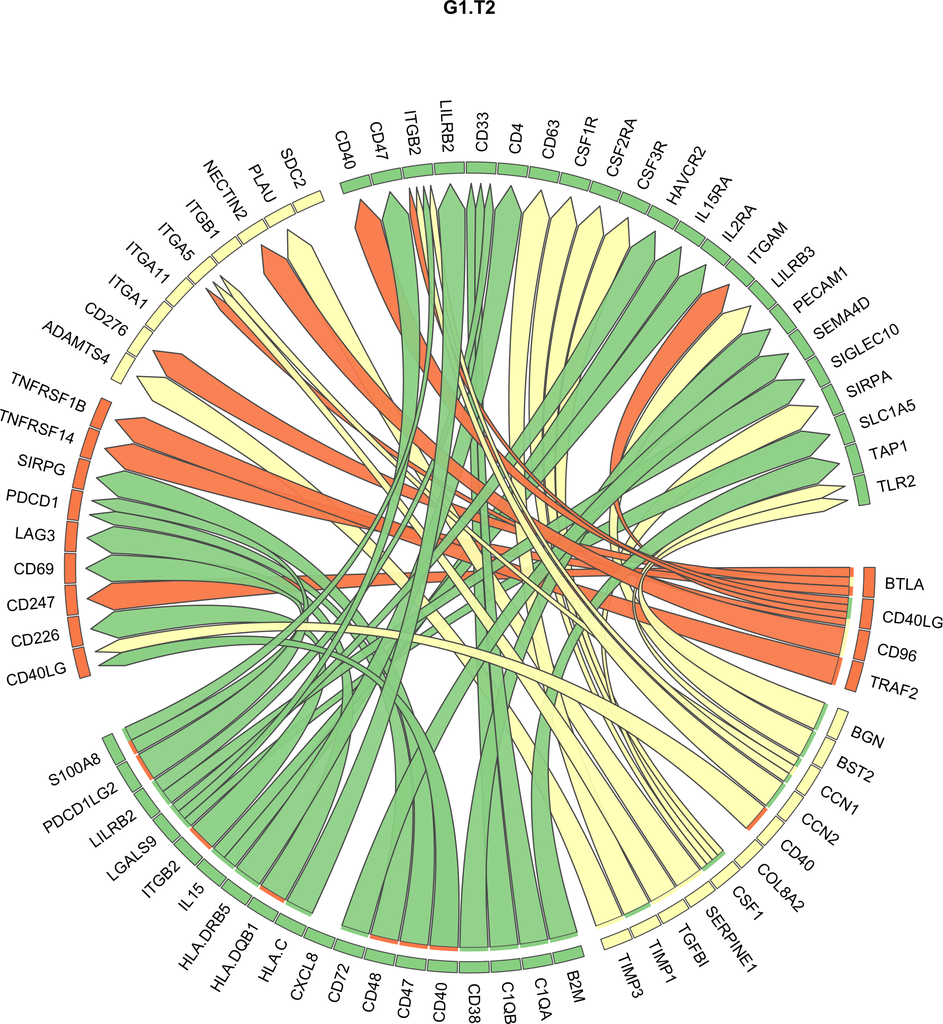

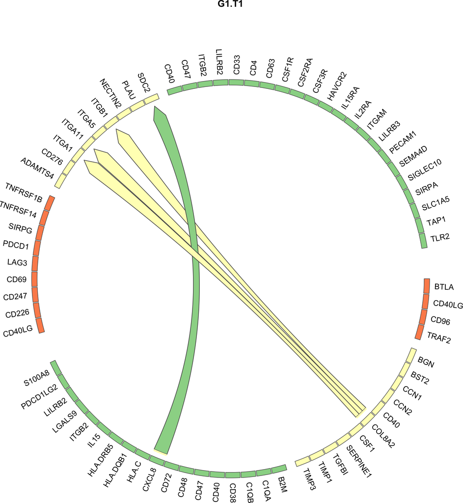

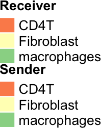

We observe more interactions that increase during therapy (“G1.T2” condition) compared to interactions that decrease (“G1.T1” condition)

*Interpretable bubble plots*

Whereas these ChordDiagrams show the most specific interactions per group, they don’t give insights into the data behind these predictions. Therefore we will now look at visualizations that indicate the different prioritization criteria used in MultiNicheNet.

In the next type of plots, we will 1) visualize the per-sample scaled product of normalized ligand and receptor pseudobulk expression, 2) visualize the scaled ligand activities, and 3) cell-type specificity.

We will now check the top interactions specific for the OnE group (G1.T2) - so these are the interactions that increase during anti-PD1 therapy.

```r
group_oi = "G1.T2"
```

```r
prioritized_tbl_oi_50 = get_top_n_lr_pairs(
  multinichenet_output_group1_t2vst1$prioritization_tables,
  top_n = 50, rank_per_group = FALSE) %>% filter(group == group_oi)
```

```r
prioritized_tbl_oi_50_omnipath = prioritized_tbl_oi_50 %>%
  inner_join(lr_network_all)
```

Now we add this to the bubble plot visualization:

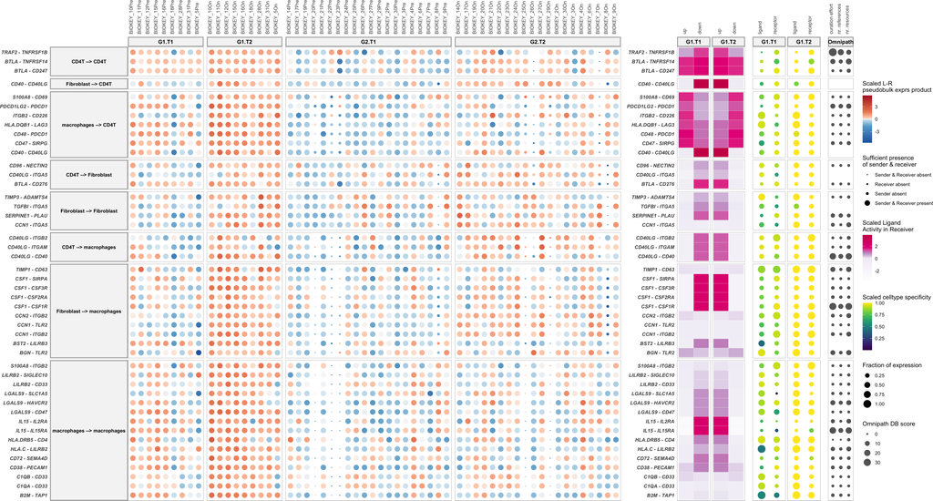

```r
plot_oi = make_sample_lr_prod_activity_plots_Omnipath(
  multinichenet_output_group1_t2vst1$prioritization_tables,
  prioritized_tbl_oi_50_omnipath)
plot_oi
```

Interestingly, we can already see that some of these interactions are only increasing in the E group, whereas others change in the NE group as well!

In practice, we always recommend generating these plots for all conditions/contrasts. To avoid that this vignette becomes too long, we will not do this here.

Now let’s do the same analysis for the NE group instead

## 2.2 2) G2.T2-G2.T1: Anti-PD1 therapy associated cell-cell communication changes in patients without clonotype expansion (NE)

*Set the required contrast of interest.*

Here, we want to compare on-treatment samples with pre-treatment samples for group NE. Therefore we can set this contrast as:

```r
contrasts_oi = c("'G2.T2-G2.T1','G2.T1-G2.T2'")
```

```r
contrast_tbl = tibble(
  contrast = c("G2.T2-G2.T1", "G2.T1-G2.T2"),
  group = c("G2.T2","G2.T1")
  )
```

### 2.2.1 Run the analysis

In this case, the first 3 steps (cell-type filtering, gene filtering, and pseudobulk expression calculation) were run for the entire dataset and are exactly the same now as for the first MultiNicheNet analysis. Therefore, we will not redo these steps, and just start with step 4, the first unique step for this second analysis.

*Differential expression (DE) analysis: determine which genes are differentially expressed*

```r
DE_info_group2 = get_DE_info(
  sce = sce,
  sample_id = sample_id, group_id = group_id, celltype_id = celltype_id,
  batches = batches, covariates = covariates,
  contrasts_oi = contrasts_oi,
  min_cells = min_cells,
  expressed_df = frq_list$expressed_df)
## [1] "DE analysis is done:"
## [1] "included cell types are:"
## [1] "CD4T"        "Fibroblast"  "macrophages"
```

Check DE output information in table with logFC and p-values for each gene-celltype-contrast:

```r
DE_info_group2$celltype_de$de_output_tidy %>% head()
## # A tibble: 6 × 9
##   gene  cluster_id   logFC logCPM      F p_val p_adj.loc p_adj contrast
##   <chr> <chr>        <dbl>  <dbl>  <dbl> <dbl>     <dbl> <dbl> <chr>
## 1 A1BG  CD4T        0.0208   5.59 0.0162 0.899     1     1     G2.T2-G2.T1
## 2 AAAS  CD4T        0.0546   4.35 0.075  0.785     1     1     G2.T2-G2.T1
## 3 AAGAB CD4T        0.02     5.01 0.0177 0.895     1     1     G2.T2-G2.T1
## 4 AAK1  CD4T        0.0902   7.06 0.397  0.531     0.93  0.93  G2.T2-G2.T1
## 5 AAMDC CD4T        0.027    3.73 0.0104 0.919     1     1     G2.T2-G2.T1
## 6 AAMP  CD4T       -0.172    5.82 1.77   0.189     0.695 0.695 G2.T2-G2.T1
```

Evaluate the distributions of p-values:

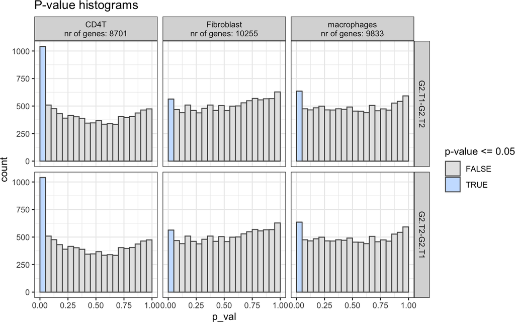

```r
DE_info_group2$hist_pvals
```

These distributions look fine (uniform distribution, except peak at p-value <= 0.05), so we will continue using these regular p-values. In case these p-value distributions look irregular, you can estimate empirical p-values as we will demonstrate in another vignette.

```r
empirical_pval = FALSE
```

```r
if(empirical_pval == TRUE){
  DE_info_emp = get_empirical_pvals(DE_info_group2$celltype_de$de_output_tidy)
  celltype_de_group2 = DE_info_emp$de_output_tidy_emp %>% select(-p_val, -p_adj) %>%
    rename(p_val = p_emp, p_adj = p_adj_emp)
} else {
  celltype_de_group2 = DE_info_group2$celltype_de$de_output_tidy
}
```

*Combine DE information for ligand-senders and receptors-receivers*

```r
sender_receiver_de = combine_sender_receiver_de(
  sender_de = celltype_de_group2,
  receiver_de = celltype_de_group2,
  senders_oi = senders_oi,
  receivers_oi = receivers_oi,
  lr_network = lr_network
)
```

```r
sender_receiver_de %>% head(20)
## # A tibble: 20 × 12
##    contrast    sender      receiver    ligand receptor lfc_ligand lfc_receptor ligand_receptor_lfc_avg p_val_ligand p_adj_ligand p_val_receptor p_adj_receptor
##    <chr>       <chr>       <chr>       <chr>  <chr>         <dbl>        <dbl>                   <dbl>        <dbl>        <dbl>          <dbl>          <dbl>
##  1 G2.T2-G2.T1 macrophages macrophages THBS1  CD36           2.78       1.18                      1.98    0.000171       0.0386          0.0186          0.589
##  2 G2.T2-G2.T1 CD4T        CD4T        CCL4L2 CCR1           3.56       0.268                     1.91    0.0000338      0.00331         0.705           0.995
##  3 G2.T2-G2.T1 CD4T        CD4T        CCL3   CCR4           3.31       0.437                     1.87    0.000739       0.033           0.0466          0.406
##  4 G2.T2-G2.T1 CD4T        macrophages CCL4L2 CCR5           3.56       0.151                     1.86    0.0000338      0.00331         0.695           1
##  5 G2.T2-G2.T1 CD4T        macrophages CCL4L2 CCR1           3.56       0.0782                    1.82    0.0000338      0.00331         0.695           1
##  6 G2.T2-G2.T1 CD4T        CD4T        CCL3   CCR1           3.31       0.268                     1.79    0.000739       0.033           0.705           0.995
##  7 G2.T2-G2.T1 CD4T        macrophages CCL3   CCR5           3.31       0.151                     1.73    0.000739       0.033           0.695           1
##  8 G2.T2-G2.T1 macrophages macrophages THBS1  SDC4           2.78       0.611                     1.70    0.000171       0.0386          0.124           0.911
##  9 G2.T2-G2.T1 CD4T        macrophages CCL3   CCR1           3.31       0.0782                    1.69    0.000739       0.033           0.695           1
## 10 G2.T2-G2.T1 Fibroblast  Fibroblast  PRG4   TLR4           2.96       0.418                     1.69    0.0017         0.176           0.147           1
## 11 G2.T2-G2.T1 CD4T        CD4T        CCL4L2 CCR5           3.56      -0.232                     1.66    0.0000338      0.00331         0.54            0.934
## 12 G2.T2-G2.T1 Fibroblast  macrophages PRG4   TLR2           2.96       0.335                     1.65    0.0017         0.176           0.0668          0.839
## 13 G2.T2-G2.T1 macrophages Fibroblast  THBS1  CD36           2.78       0.495                     1.64    0.000171       0.0386          0.302           1
## 14 G2.T2-G2.T1 macrophages CD4T        THBS1  SDC4           2.78       0.487                     1.63    0.000171       0.0386          0.235           0.75
## 15 G2.T2-G2.T1 Fibroblast  CD4T        PRG4   CD44           2.96       0.299                     1.63    0.0017         0.176           0.0133          0.211
## 16 G2.T2-G2.T1 macrophages macrophages THBS1  CD47           2.78       0.379                     1.58    0.000171       0.0386          0.054           0.793
## 17 G2.T1-G2.T2 CD4T        Fibroblast  CXCL14 CXCR4          2.53       0.573                     1.55    0.000151       0.0106          0.232           1
## 18 G2.T2-G2.T1 CD4T        CD4T        CCL3   CCR5           3.31      -0.232                     1.54    0.000739       0.033           0.54            0.934
## 19 G2.T2-G2.T1 Fibroblast  Fibroblast  PRG4   CD44           2.96       0.103                     1.53    0.0017         0.176           0.639           1
## 20 G2.T2-G2.T1 macrophages macrophages THBS1  ITGA6          2.78       0.226                     1.50    0.000171       0.0386          0.511           1
```

*Ligand activity prediction: use the DE analysis output to predict the activity of ligands in receiver cell types and infer their potential target genes*

We will first inspect the geneset_oi-vs-background ratios for the default tresholds:

```r
geneset_assessment = contrast_tbl$contrast %>%
  lapply(
    process_geneset_data,
    celltype_de_group2, logFC_threshold, p_val_adj, p_val_threshold
  ) %>%
  bind_rows()
geneset_assessment
## # A tibble: 6 × 12
##   cluster_id  n_background n_geneset_up n_geneset_down prop_geneset_up prop_geneset_down in_range_up in_range_down contrast    logFC_threshold p_val_threshold adjusted
##   <chr>              <int>        <int>          <int>           <dbl>             <dbl> <lgl>       <lgl>         <chr>                 <dbl>           <dbl> <lgl>
## 1 CD4T                8701          309            232         0.0355            0.0267  TRUE        TRUE          G2.T2-G2.T1             0.5            0.05 FALSE
## 2 Fibroblast         10255          183             75         0.0178            0.00731 TRUE        TRUE          G2.T2-G2.T1             0.5            0.05 FALSE
## 3 macrophages         9833          243            185         0.0247            0.0188  TRUE        TRUE          G2.T2-G2.T1             0.5            0.05 FALSE
## 4 CD4T                8701          232            309         0.0267            0.0355  TRUE        TRUE          G2.T1-G2.T2             0.5            0.05 FALSE
## 5 Fibroblast         10255           75            183         0.00731           0.0178  TRUE        TRUE          G2.T1-G2.T2             0.5            0.05 FALSE
## 6 macrophages         9833          185            243         0.0188            0.0247  TRUE        TRUE          G2.T1-G2.T2             0.5            0.05 FALSE
```

We can see here that for all cell type / contrast combinations, all geneset/background ratio’s are within the recommended range (`in_range_up` and `in_range_down` columns). When these geneset/background ratio’s would not be within the recommended ranges, we should interpret ligand activity results for these cell types with more caution, or use different thresholds (for these or all cell types).

```r
ligand_activities_targets_DEgenes = suppressMessages(suppressWarnings(
  get_ligand_activities_targets_DEgenes(
    receiver_de = celltype_de_group2,
    receivers_oi = intersect(receivers_oi, celltype_de_group2$cluster_id %>% unique()),
    ligand_target_matrix = ligand_target_matrix,
    logFC_threshold = logFC_threshold,
    p_val_threshold = p_val_threshold,
    p_val_adj = p_val_adj,
    top_n_target = top_n_target,
    verbose = TRUE,
    n.cores = n.cores
  )
))
```

*Prioritization: rank cell-cell communication patterns through multi-criteria prioritization*

```r
sender_receiver_tbl = sender_receiver_de %>% distinct(sender, receiver)

metadata_combined = SummarizedExperiment::colData(sce) %>% tibble::as_tibble()

if(!is.na(batches)){
  grouping_tbl = metadata_combined[,c(sample_id, group_id, batches)] %>%
    tibble::as_tibble() %>% distinct()
  colnames(grouping_tbl) = c("sample","group",batches)
} else {
  grouping_tbl = metadata_combined[,c(sample_id, group_id)] %>%
    tibble::as_tibble() %>% distinct()
  colnames(grouping_tbl) = c("sample","group")
}

prioritization_tables = suppressMessages(generate_prioritization_tables(
    sender_receiver_info = abundance_expression_info$sender_receiver_info,
    sender_receiver_de = sender_receiver_de,
    ligand_activities_targets_DEgenes = ligand_activities_targets_DEgenes,
    contrast_tbl = contrast_tbl,
    sender_receiver_tbl = sender_receiver_tbl,
    grouping_tbl = grouping_tbl,
    scenario = "regular", # all prioritization criteria will be weighted equally
    fraction_cutoff = fraction_cutoff,
    abundance_data_receiver = abundance_expression_info$abundance_data_receiver,
    abundance_data_sender = abundance_expression_info$abundance_data_sender,
    ligand_activity_down = ligand_activity_down
  ))
```

*Compile the MultiNicheNet output object*

```r
multinichenet_output_group2_t2vst1 = list(
    celltype_info = abundance_expression_info$celltype_info,
    celltype_de = celltype_de_group2,
    sender_receiver_info = abundance_expression_info$sender_receiver_info,
    sender_receiver_de =  sender_receiver_de,
    ligand_activities_targets_DEgenes = ligand_activities_targets_DEgenes,
    prioritization_tables = prioritization_tables,
    grouping_tbl = grouping_tbl,
    lr_target_prior_cor = tibble()
  )
multinichenet_output_group2_t2vst1 = make_lite_output(multinichenet_output_group2_t2vst1)
```

### 2.2.2 Interpret the analysis

*Summarizing ChordDiagram circos plots*

We will look here at the top 50 predictions across all contrasts, senders, and receivers of interest.

```r
prioritized_tbl_oi_all = get_top_n_lr_pairs(
  multinichenet_output_group2_t2vst1$prioritization_tables,
  top_n = 50,
  rank_per_group = FALSE
  )
```

```r
prioritized_tbl_oi =
  multinichenet_output_group2_t2vst1$prioritization_tables$group_prioritization_tbl %>%
  filter(id %in% prioritized_tbl_oi_all$id) %>%
  distinct(id, sender, receiver, ligand, receptor, group) %>%
  left_join(prioritized_tbl_oi_all)
prioritized_tbl_oi$prioritization_score[is.na(prioritized_tbl_oi$prioritization_score)] = 0

senders_receivers = union(prioritized_tbl_oi$sender %>% unique(), prioritized_tbl_oi$receiver %>% unique()) %>% sort()

colors_sender = RColorBrewer::brewer.pal(n = length(senders_receivers), name = 'Spectral') %>% magrittr::set_names(senders_receivers)
colors_receiver = RColorBrewer::brewer.pal(n = length(senders_receivers), name = 'Spectral') %>% magrittr::set_names(senders_receivers)

circos_list = make_circos_group_comparison(prioritized_tbl_oi, colors_sender, colors_receiver)
```

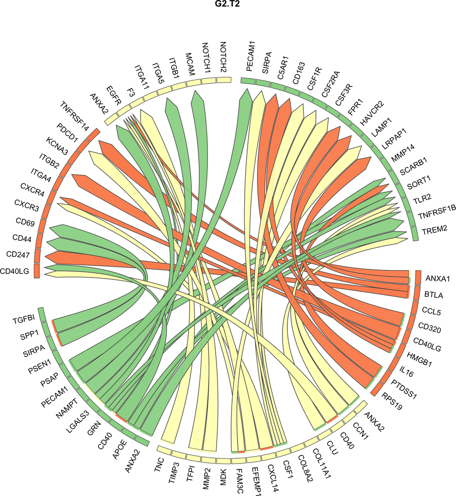

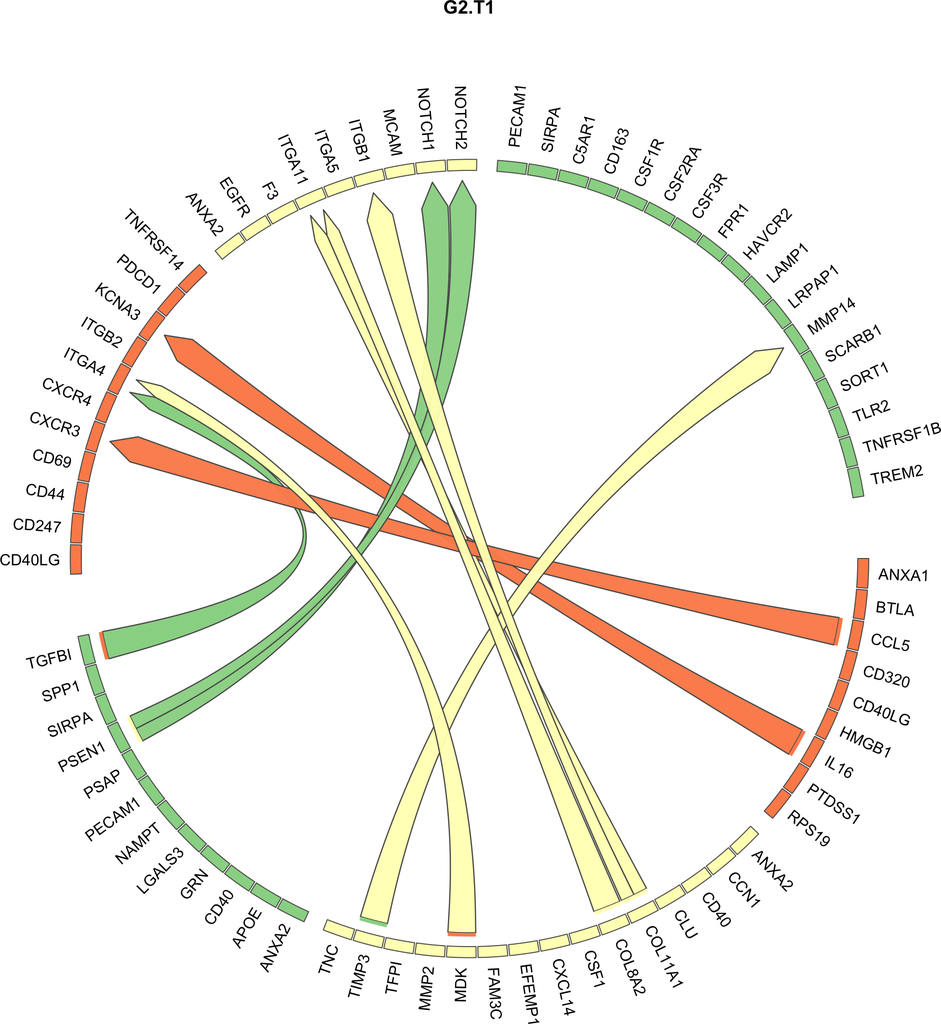

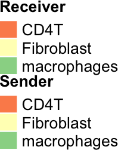

Also in this group of patients we see rather an increase on therapy compared to pre-therapy.

*Interpretable bubble plots*

```r
group_oi = "G2.T2"
```

```r
prioritized_tbl_oi_50 = get_top_n_lr_pairs(
  multinichenet_output_group2_t2vst1$prioritization_tables,
  top_n = 50, rank_per_group = FALSE) %>% filter(group == group_oi)
```

```r
prioritized_tbl_oi_50_omnipath = prioritized_tbl_oi_50 %>%
  inner_join(lr_network_all)
```

Now we add this to the bubble plot visualization:

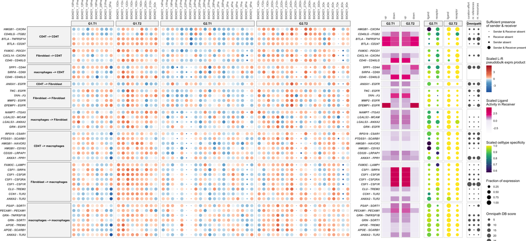

```r
plot_oi = make_sample_lr_prod_activity_plots_Omnipath(
  multinichenet_output_group2_t2vst1$prioritization_tables,
  prioritized_tbl_oi_50_omnipath)
plot_oi
```

So interesting observation: even though the NE group is characterized by a lack of T cell clonotype expansion after therapy, there are still clear therapy-induced differences on gene expression and cell-cell communication.

Interestingly, we can see here as well that some interactions are only increasing in the NE group, whereas others change in the E group as well!

This brings us to the next research question: do some interactions increase/decrease more in the E group vs the NE group or vice versa?

## 2.3 3A) E-vs-NE: simple comparison of prioritized anti-PD1 therapy-associated CCC patterns

To address this question, we will first do a simple analysis. We will just compare the prioritization scores between the E and the NE group, to find CCC patterns that are most different between the E and NE group.

*Set up the comparisons*

```r
comparison_table = multinichenet_output_group1_t2vst1$prioritization_tables$group_prioritization_tbl %>%
  select(group, id, prioritization_score) %>%
  rename(prioritization_score_group1 = prioritization_score) %>%
  mutate(group = case_when(
    group == "G1.T1" ~ "timepoint1",
    group == "G1.T2" ~ "timepoint2",
    TRUE ~ group)
    ) %>%
  inner_join(
    multinichenet_output_group2_t2vst1$prioritization_tables$group_prioritization_tbl %>%
      select(group, id, prioritization_score) %>%
      rename(prioritization_score_group2 = prioritization_score) %>%
  mutate(group = case_when(
    group == "G2.T1" ~ "timepoint1",
    group == "G2.T2" ~ "timepoint2",
    TRUE ~ group)
    )
  ) %>%
  mutate(difference_group1_vs_group2 = prioritization_score_group1 - prioritization_score_group2)
```

Let’s now inspect some of the top interactions that got much higher scores in the E group

```r
comparison_table %>%
  arrange(-difference_group1_vs_group2) %>%
  filter(prioritization_score_group1 > 0.80)
## # A tibble: 852 × 5
##    group      id                                        prioritization_score_group1 prioritization_score_group2 difference_group1_vs_group2
##    <chr>      <chr>                                                           <dbl>                       <dbl>                       <dbl>
##  1 timepoint2 CCL5_CCR1_Fibroblast_macrophages                                0.844                       0.375                       0.468
##  2 timepoint2 BST2_LILRA5_Fibroblast_macrophages                              0.830                       0.365                       0.465
##  3 timepoint2 CDH2_CDH2_Fibroblast_Fibroblast                                 0.806                       0.351                       0.455
##  4 timepoint2 CCL2_CCR2_Fibroblast_macrophages                                0.838                       0.397                       0.441
##  5 timepoint2 CCL5_SDC4_Fibroblast_macrophages                                0.853                       0.425                       0.427
##  6 timepoint2 CCL5_CCR5_Fibroblast_macrophages                                0.800                       0.374                       0.426
##  7 timepoint2 BST2_LILRB3_Fibroblast_macrophages                              0.924                       0.513                       0.411
##  8 timepoint2 TNFSF10_TNFRSF10B_macrophages_Fibroblast                        0.856                       0.447                       0.409
##  9 timepoint2 TNFSF10_TNFRSF10B_Fibroblast_Fibroblast                         0.830                       0.446                       0.384
## 10 timepoint2 TNFSF10_TNFRSF10B_macrophages_macrophages                       0.871                       0.509                       0.361
## # ℹ 842 more rows
```

Let’s now inspect some of the top interactions that got much higher scores in the NE group

```r
comparison_table %>%
  arrange(difference_group1_vs_group2) %>%
  filter(prioritization_score_group2 > 0.80)
## # A tibble: 574 × 5
##    group      id                                   prioritization_score_group1 prioritization_score_group2 difference_group1_vs_group2
##    <chr>      <chr>                                                      <dbl>                       <dbl>                       <dbl>
##  1 timepoint2 IGF2_ITGA6_Fibroblast_macrophages                          0.366                       0.800                      -0.434
##  2 timepoint1 TIMP3_ADAM17_Fibroblast_macrophages                        0.518                       0.868                      -0.350
##  3 timepoint2 LAMB1_ITGA6_Fibroblast_macrophages                         0.471                       0.820                      -0.348
##  4 timepoint2 ANXA1_EGFR_CD4T_Fibroblast                                 0.583                       0.891                      -0.308
##  5 timepoint2 CCN1_ITGA6_Fibroblast_macrophages                          0.520                       0.818                      -0.298
##  6 timepoint2 PI16_TNFRSF21_Fibroblast_macrophages                       0.520                       0.814                      -0.294
##  7 timepoint2 MELTF_TFRC_macrophages_macrophages                         0.523                       0.815                      -0.292
##  8 timepoint2 IL2_IL2RG_CD4T_CD4T                                        0.550                       0.831                      -0.281
##  9 timepoint2 IL2_CD53_CD4T_CD4T                                         0.573                       0.853                      -0.280
## 10 timepoint1 LILRB2_CD33_macrophages_macrophages                        0.591                       0.864                      -0.273
## # ℹ 564 more rows
```

### 2.3.1 Interactions increasing after therapy in the E group

Visualize now interactions that are in the top250 interactions for the contrast On-vs-Pre in the E group.

*E-group specific*

Of these, we will first zoom into the top25 interactions with biggest difference in the E-vs-NE group.

```r
group_oi = "G1.T2"
```

```r
prioritized_tbl_oi_250 = get_top_n_lr_pairs(
  multinichenet_output_group1_t2vst1$prioritization_tables,
  top_n = 250, rank_per_group = FALSE) %>%
  filter(group == group_oi) %>%
  inner_join(lr_network_all)
```

```r
ids_group1_vs_group2 = comparison_table %>% filter(group == "timepoint2" & id %in% prioritized_tbl_oi_250$id) %>% top_n(25, difference_group1_vs_group2) %>% filter(difference_group1_vs_group2 > 0) %>% pull(id)
```

```r
prioritized_tbl_oi_250_unique_E = prioritized_tbl_oi_250 %>%
  filter(id %in% ids_group1_vs_group2)
```

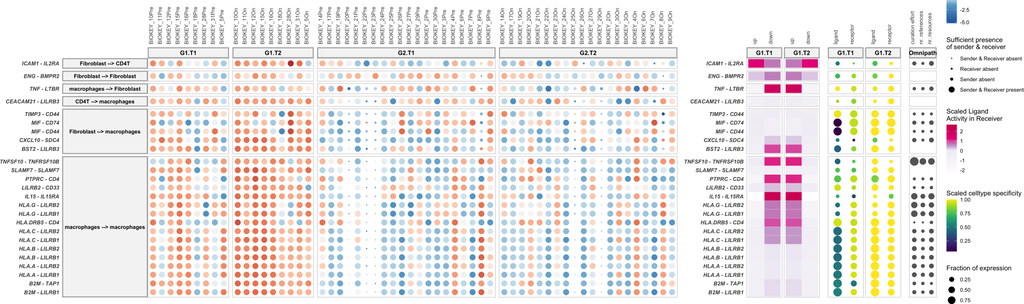

```r
plot_oi = make_sample_lr_prod_activity_plots_Omnipath(
  multinichenet_output_group1_t2vst1$prioritization_tables,
  prioritized_tbl_oi_250_unique_E)
plot_oi
```

*shared between E-group and NE-group*

Now we will look at the interactions with a very similar score between E and NE. So these interactions are interactions that increase after therapy, but shared between group E and NE.

```r
ids_E_shared_NE = comparison_table %>% filter(group == "timepoint2" & id %in% prioritized_tbl_oi_250$id)  %>% mutate(deviation_from_0 = abs(0-difference_group1_vs_group2)) %>% top_n(25, -deviation_from_0) %>% arrange(deviation_from_0) %>% pull(id)
```

```r
prioritized_tbl_oi_250_shared_E_NE = prioritized_tbl_oi_250 %>%
  filter(id %in% ids_E_shared_NE)
```

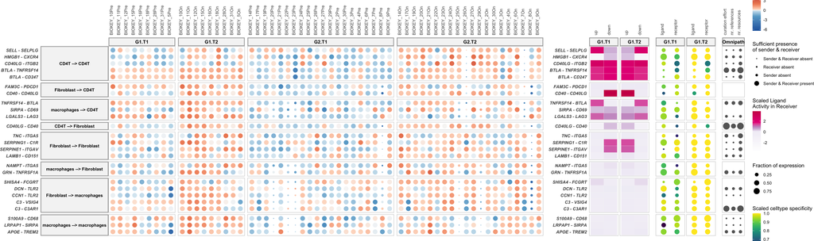

```r
plot_oi = make_sample_lr_prod_activity_plots_Omnipath(
  multinichenet_output_group1_t2vst1$prioritization_tables,
  prioritized_tbl_oi_250_shared_E_NE)
plot_oi
```

### 2.3.2 Interactions decreasing after therapy in the E group

Visualize now interactions that are in the top250 interactions for the contrast On-vs-Pre in the E group. We will focus on decreasing interactions here.

*E-group specific*

Of these, we will first zoom into the top10 interactions with biggest difference in the E-vs-NE group.

```r
group_oi = "G1.T1"
```

```r
prioritized_tbl_oi_250 = get_top_n_lr_pairs(
  multinichenet_output_group1_t2vst1$prioritization_tables,
  top_n = 250, rank_per_group = FALSE) %>%
  filter(group == group_oi) %>%
  inner_join(lr_network_all)
```

```r
ids_group1_vs_group2 = comparison_table %>% filter(group == "timepoint1" & id %in% prioritized_tbl_oi_250$id) %>% top_n(10, difference_group1_vs_group2) %>% filter(difference_group1_vs_group2 > 0) %>% pull(id)
```

```r
prioritized_tbl_oi_250_unique_E = prioritized_tbl_oi_250 %>%
  filter(id %in% ids_group1_vs_group2)
```

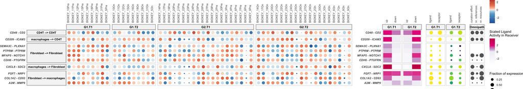

```r
plot_oi = make_sample_lr_prod_activity_plots_Omnipath(
  multinichenet_output_group1_t2vst1$prioritization_tables,
  prioritized_tbl_oi_250_unique_E)
plot_oi
```

*shared between E-group and NE-group*

Now we will look at the interactions with a very similar score between E and NE. So these interactions are interactions that decrease after therapy, but shared between group E and NE.

```r
ids_E_shared_NE = comparison_table %>% filter(group == "timepoint1" & id %in% prioritized_tbl_oi_250$id) %>% mutate(deviation_from_0 = abs(0-difference_group1_vs_group2)) %>% top_n(10, -deviation_from_0) %>% arrange(deviation_from_0) %>% pull(id)
```

```r
prioritized_tbl_oi_250_shared_E_NE = prioritized_tbl_oi_250 %>%
  filter(id %in% ids_E_shared_NE)
```

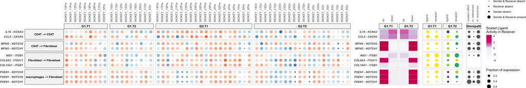

```r
plot_oi = make_sample_lr_prod_activity_plots_Omnipath(
  multinichenet_output_group1_t2vst1$prioritization_tables,
  prioritized_tbl_oi_250_shared_E_NE)
plot_oi
```

### 2.3.3 Interactions increasing after therapy in the NE group

Visualize now interactions that are in the top250 interactions for the contrast On-vs-Pre in the E group.

To avoid making this vignette too long, we will not explicitly show this for the NE group since the code is the same as for the E group, you only need to change the `group_oi` to `"G2.T2"`.

### 2.3.4 Conclusions of these comparisons

Whereas these comparisons are quite intuitive, they are also relatively arbitrary (requiring cutoffs to compare interactions) and suboptimal. They are suboptimal because the prioritization scores of interactions are relative versus the other interactions within a group. If there is a difference in **effect size** of the therapy-induced changes in CCC, comparing the final prioritization scores may not be optimal.

Therefore, we will now discuss another way to infer group-specific therapy-associated CCC patterns: namely setting up complex multifactorial contrasts in the DE analysis of a MultiNicheNet analysis.

## 2.4 3B) E-vs-NE: MultiNicheNet analysis with complex contrast setting: (G1.T2-G1.T1)-(G2.T2-G2.T1)

*Set the required contrasts*

For this analysis, we want to compare how cell-cell communication changes On-vs-Pre anti-PD1 therapy are different between responder/expander patients vs non-responder/expander patients. In other words, we want to study how both patient groups react differently to the therapy.

To perform this comparison, we need to set the following contrasts:

```r
contrasts_oi = c("'(G1.T2-G1.T1)-(G2.T2-G2.T1)','(G2.T2-G2.T1)-(G1.T2-G1.T1)','(G1.T1-G1.T2)-(G2.T1-G2.T2)','(G2.T1-G2.T2)-(G1.T1-G1.T2)'")
contrast_tbl = tibble(contrast =
                        c("(G1.T2-G1.T1)-(G2.T2-G2.T1)",
                          "(G2.T2-G2.T1)-(G1.T2-G1.T1)",
                          "(G1.T1-G1.T2)-(G2.T1-G2.T2)",
                          "(G2.T1-G2.T2)-(G1.T1-G1.T2)"),
                      group = c("G1.T2","G2.T2","G1.T1","G2.T1"))
```

To understand this, let’s take a look at the first contrasts of interest: `(G1.T2-G1.T1)-(G2.T2-G2.T1)`. As you can see, the first part of the expression: `(G1.T2-G1.T1)` will cover differences on-vs-pre therapy in group1, the second part `(G2.T2-G2.T1)` in the NE group. By adding the minus sign, we can compare these differences between the E and NE group.

### 2.4.1 Run the analysis

In this case, the first 3 steps (cell-type filtering, gene filtering, and pseudobulk expression calculation) were run for the entire dataset and are exactly the same now as for the first MultiNicheNet analysis. Therefore, we will not redo these steps, and just start with step 4, the first unique step for this second analysis.

*Differential expression (DE) analysis: determine which genes are differentially expressed*

```r
DE_info = get_DE_info(
  sce = sce,
  sample_id = sample_id, group_id = group_id, celltype_id = celltype_id,
  batches = batches, covariates = covariates,
  contrasts_oi = contrasts_oi,
  min_cells = min_cells,
  expressed_df = frq_list$expressed_df)
## [1] "DE analysis is done:"
## [1] "included cell types are:"
## [1] "CD4T"        "Fibroblast"  "macrophages"
```

Check DE output information in table with logFC and p-values for each gene-celltype-contrast:

```r
DE_info$celltype_de$de_output_tidy %>% head()
## # A tibble: 6 × 9
##   gene  cluster_id   logFC logCPM       F p_val p_adj.loc p_adj contrast
##   <chr> <chr>        <dbl>  <dbl>   <dbl> <dbl>     <dbl> <dbl> <chr>
## 1 A1BG  CD4T       -0.209    5.59 0.662   0.419         1     1 (G1.T2-G1.T1)-(G2.T2-G2.T1)
## 2 AAAS  CD4T       -0.123    4.35 0.173   0.679         1     1 (G1.T2-G1.T1)-(G2.T2-G2.T1)
## 3 AAGAB CD4T       -0.0782   5.01 0.119   0.731         1     1 (G1.T2-G1.T1)-(G2.T2-G2.T1)
## 4 AAK1  CD4T       -0.2      7.06 0.719   0.4           1     1 (G1.T2-G1.T1)-(G2.T2-G2.T1)
## 5 AAMDC CD4T        0.0439   3.73 0.0123  0.912         1     1 (G1.T2-G1.T1)-(G2.T2-G2.T1)
## 6 AAMP  CD4T        0.0137   5.82 0.00469 0.946         1     1 (G1.T2-G1.T1)-(G2.T2-G2.T1)
```

Evaluate the distributions of p-values:

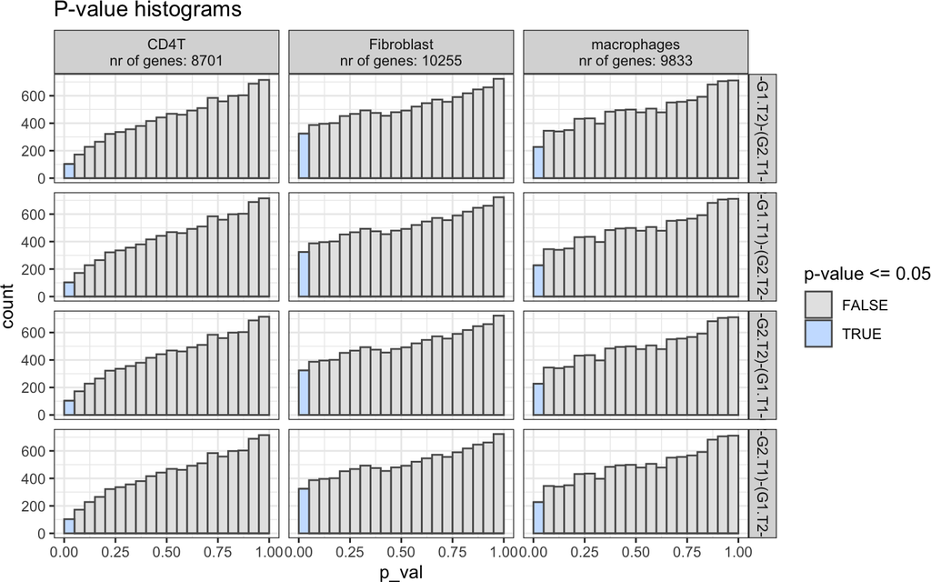

```r
DE_info$hist_pvals
```

These distributions do not look fine. We expect a uniform distribution, or a uniform distribution with a peak at p-value <= 0.05. Irregularities in the p-value distribution might point to issues in the DE model definition. For example in case we did not add all important covariates, or if there is substructure present in the groups, etc. In such cases, we can use the empiricall null procedure from Efron. This is a procedure that will define empirical p-values based on the observed distribution of the test statistic (here: logFC) and not based on the theoretical distribution. This approach has also been used in the Saturn package: https://github.com/statOmics/satuRn. We only recommend this if the p-value distributions point to possible issues, which is the case here.

To continue with the empirical p-values:

```r
empirical_pval = TRUE
```

```r
if(empirical_pval == TRUE){
  DE_info_emp = get_empirical_pvals(DE_info$celltype_de$de_output_tidy)
  celltype_de = DE_info_emp$de_output_tidy_emp %>% select(-p_val, -p_adj) %>%
    rename(p_val = p_emp, p_adj = p_adj_emp)
} else {
  celltype_de = DE_info$celltype_de$de_output_tidy
}
```

Check empirical p-value distributions:

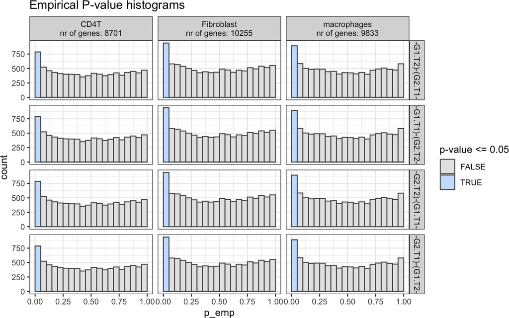

```r
DE_info_emp$hist_pvals_emp
```

These look already better now.

The following plots show how well the correction worked. The green fitted curve should fit well with the histogram. If not, this might point to some issues in the DE model definition.

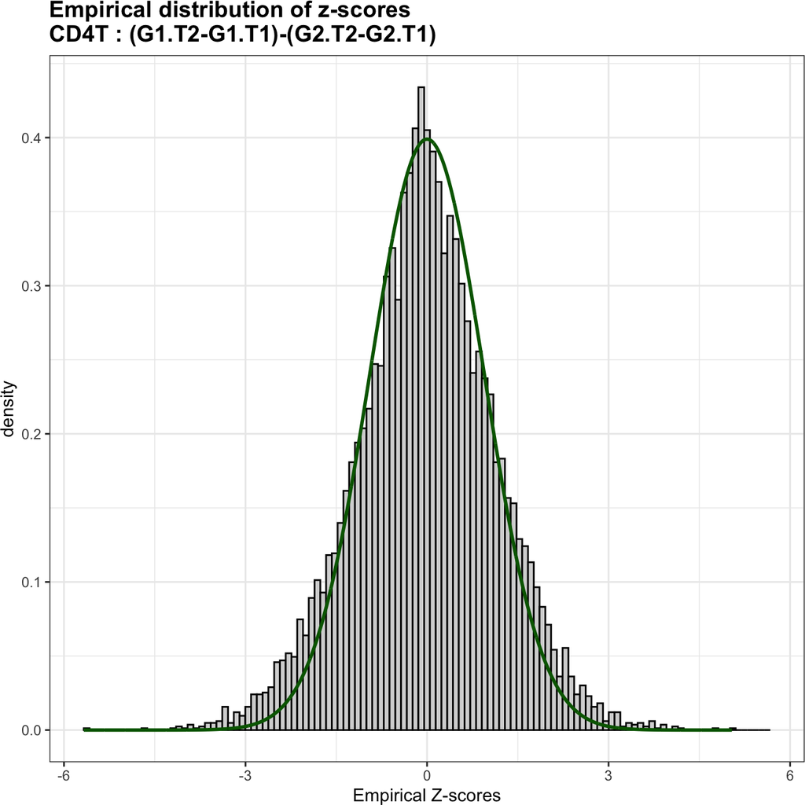

```
##
## $`CD4T.(G2.T2-G2.T1)-(G1.T2-G1.T1)`
```

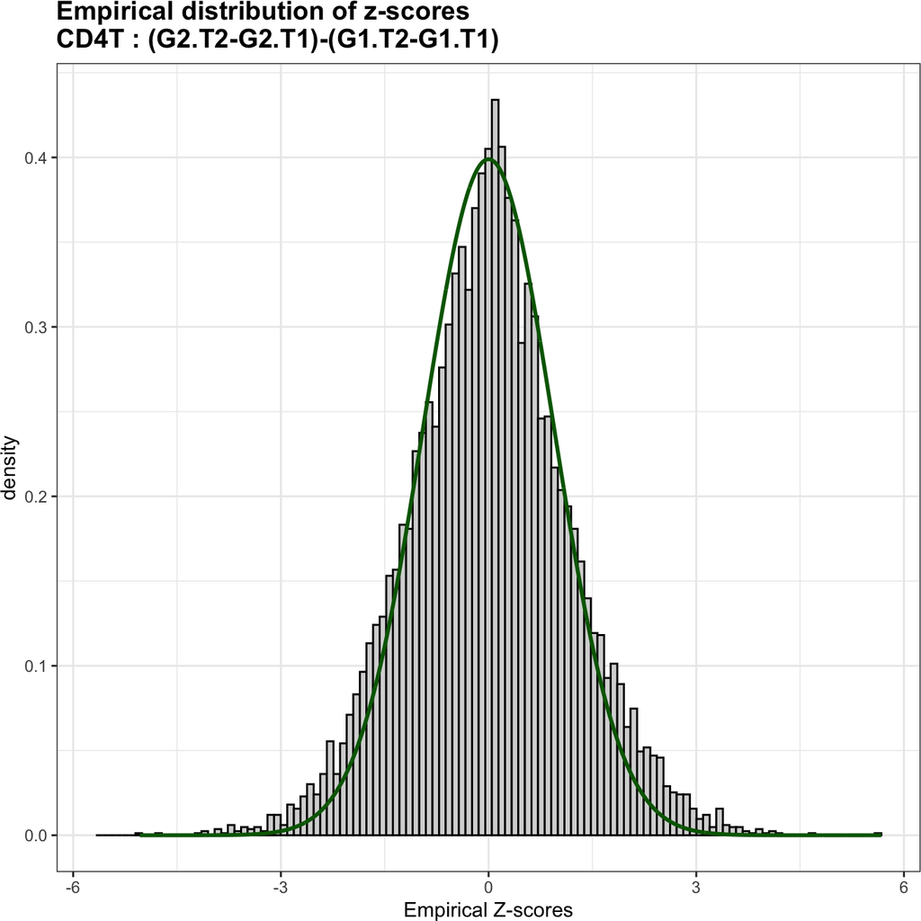

```
##
## $`CD4T.(G1.T1-G1.T2)-(G2.T1-G2.T2)`
```

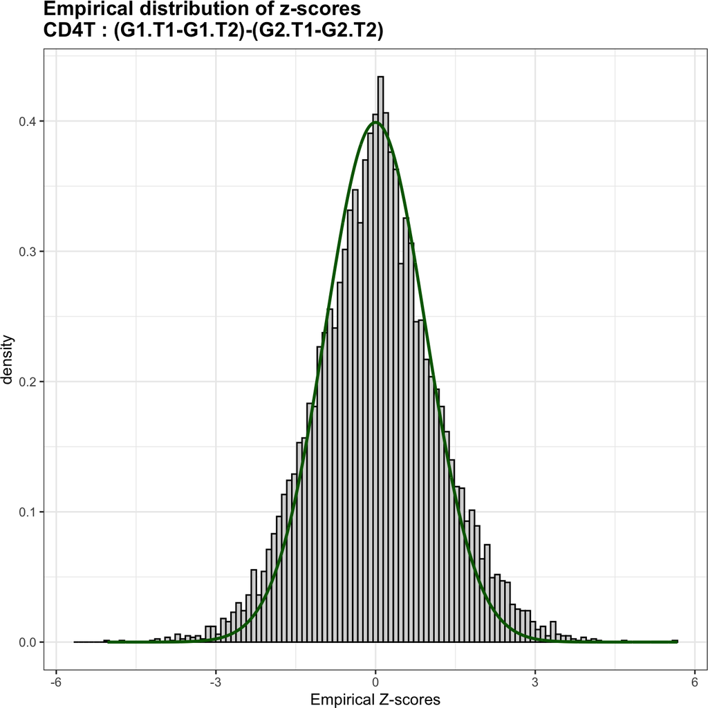

```
##
## $`CD4T.(G2.T1-G2.T2)-(G1.T1-G1.T2)`
```

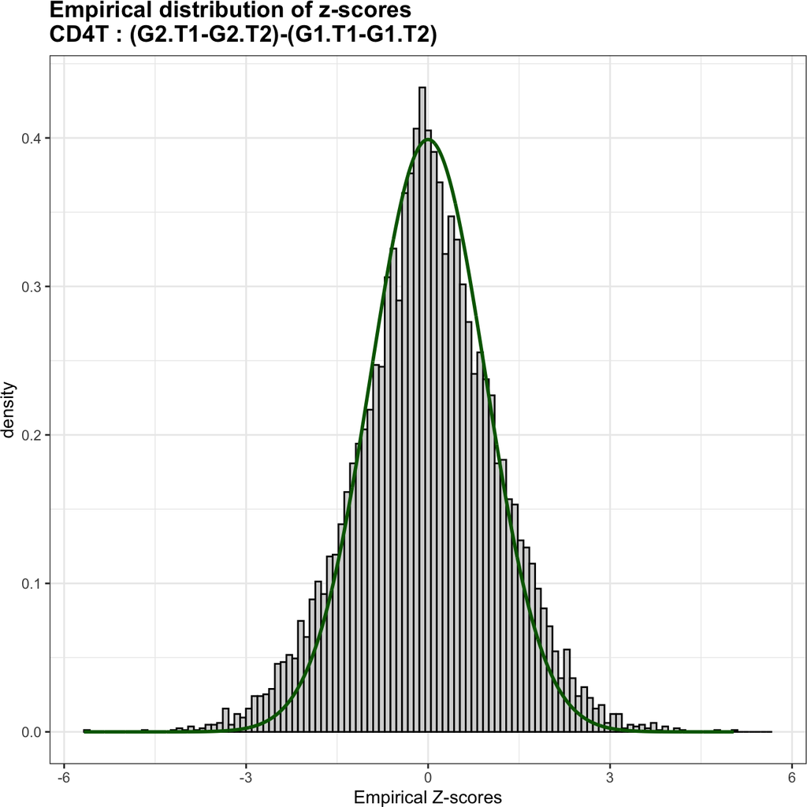

```
##
## $`Fibroblast.(G1.T2-G1.T1)-(G2.T2-G2.T1)`
```

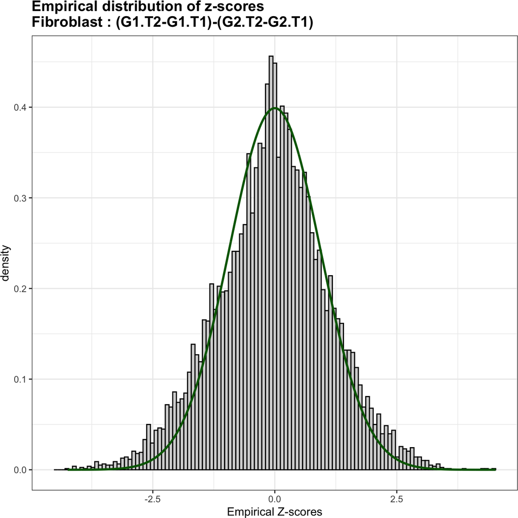

```
##
## $`Fibroblast.(G2.T2-G2.T1)-(G1.T2-G1.T1)`
```

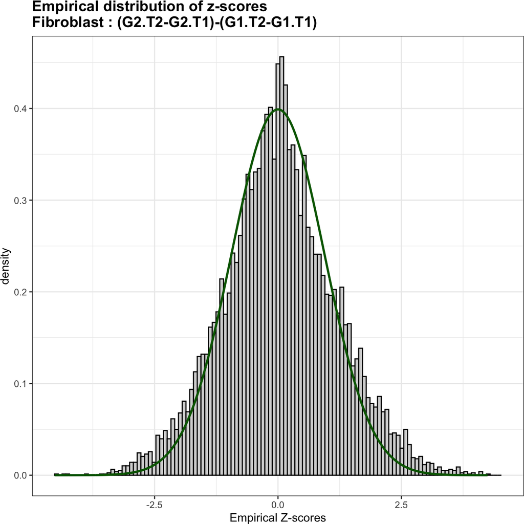

```
##
## $`Fibroblast.(G1.T1-G1.T2)-(G2.T1-G2.T2)`
```

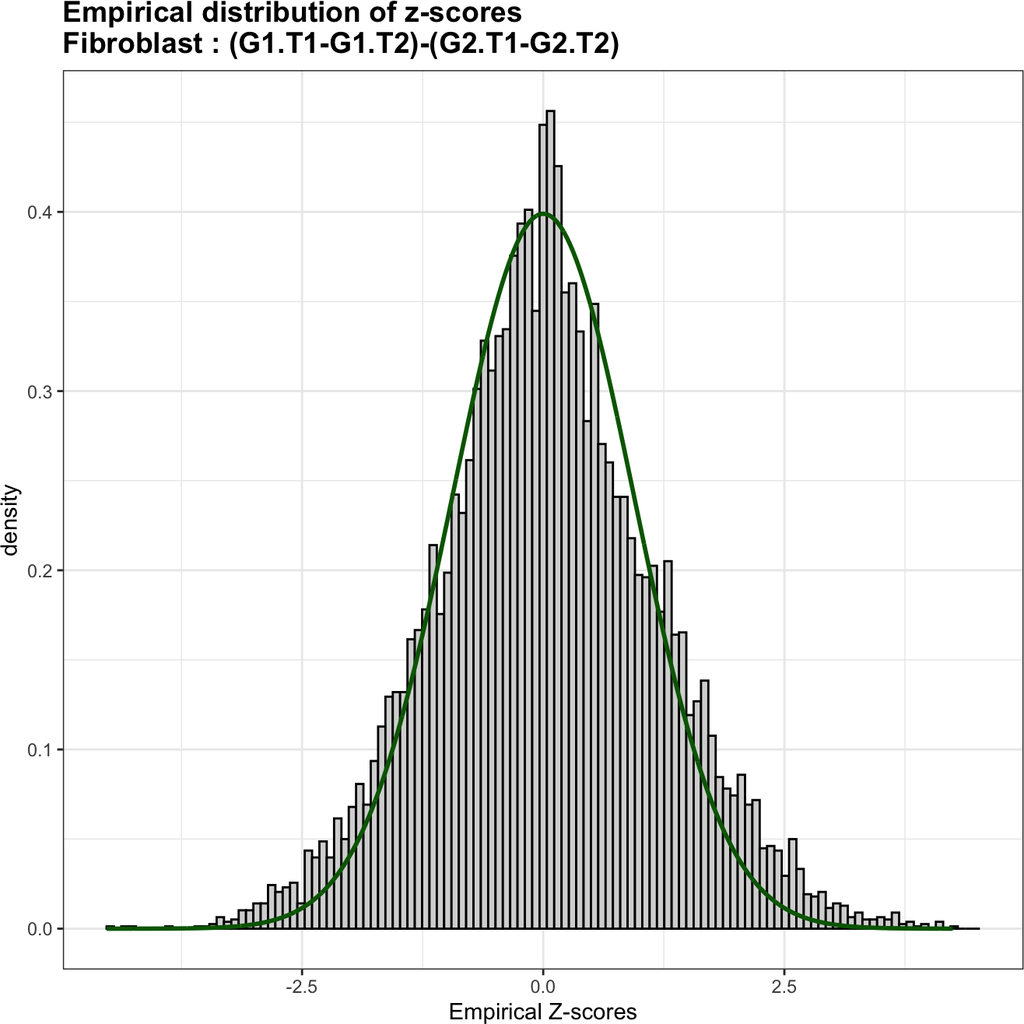

```
##
## $`Fibroblast.(G2.T1-G2.T2)-(G1.T1-G1.T2)`
```

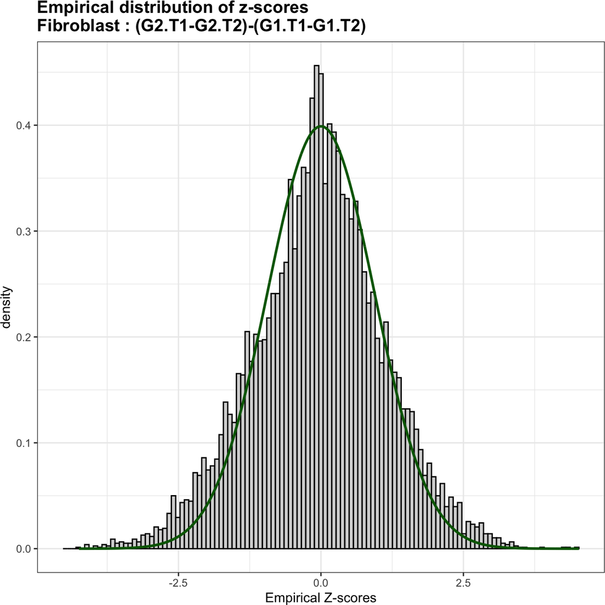

```
##
## $`macrophages.(G1.T2-G1.T1)-(G2.T2-G2.T1)`
```

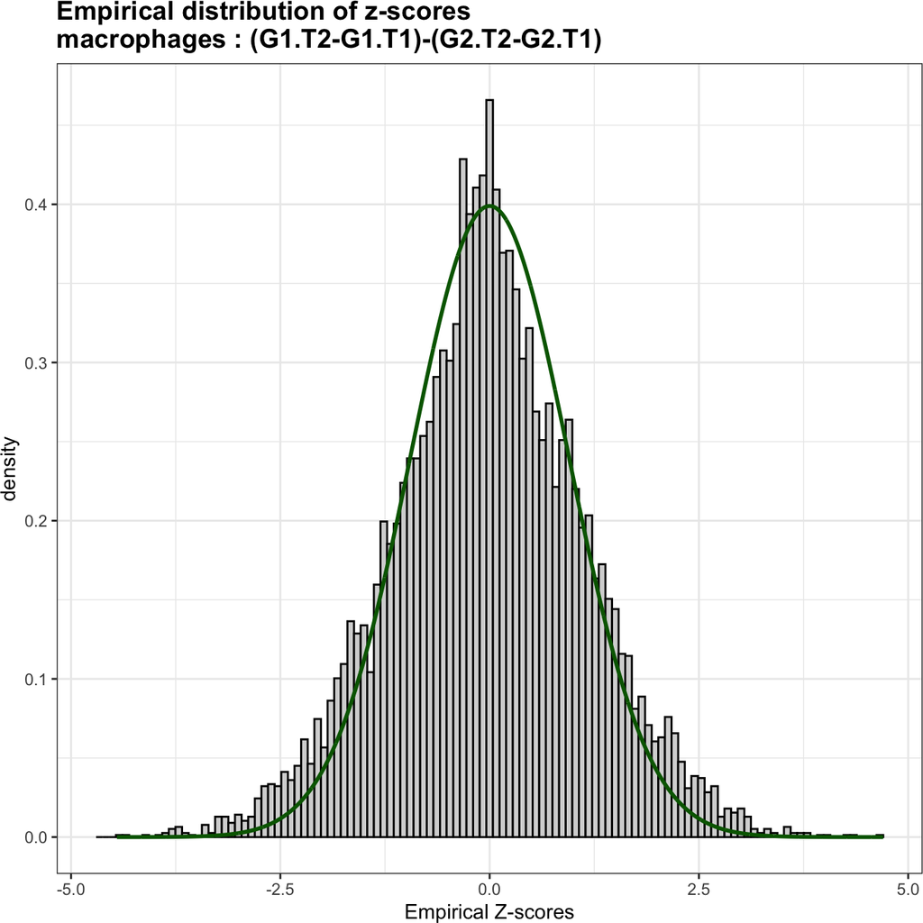

```
##
## $`macrophages.(G2.T2-G2.T1)-(G1.T2-G1.T1)`
```

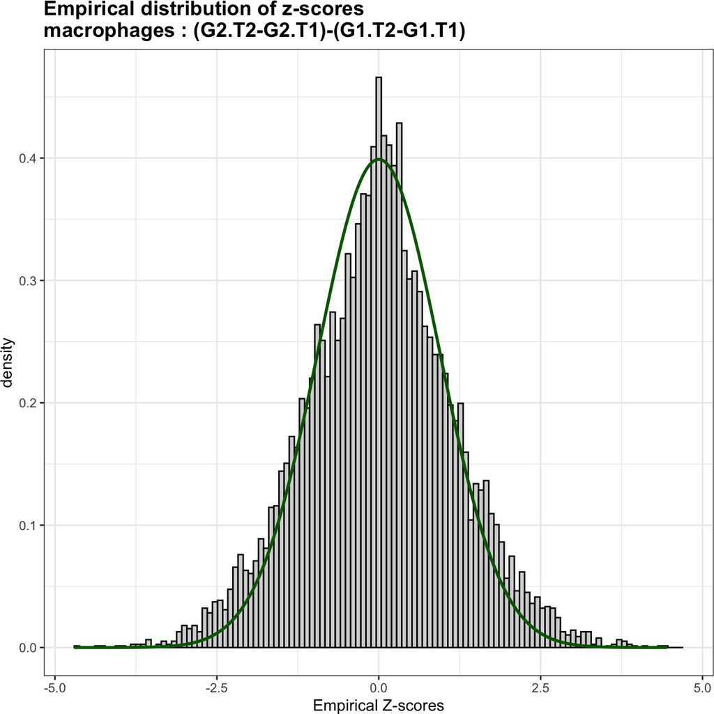

```
##
## $`macrophages.(G1.T1-G1.T2)-(G2.T1-G2.T2)`
```

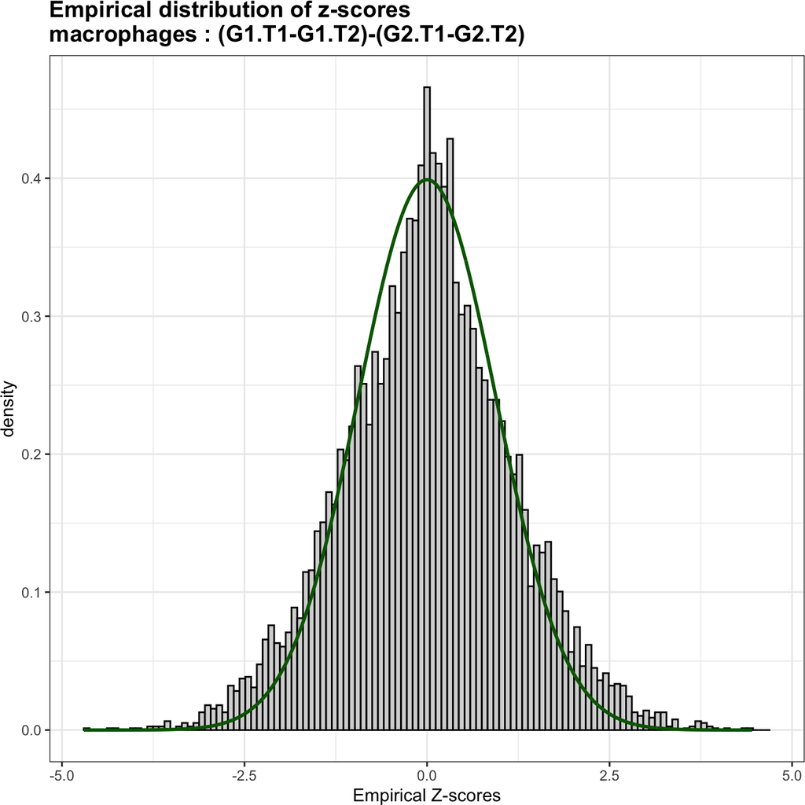

```
##
## $`macrophages.(G2.T1-G2.T2)-(G1.T1-G1.T2)`
```

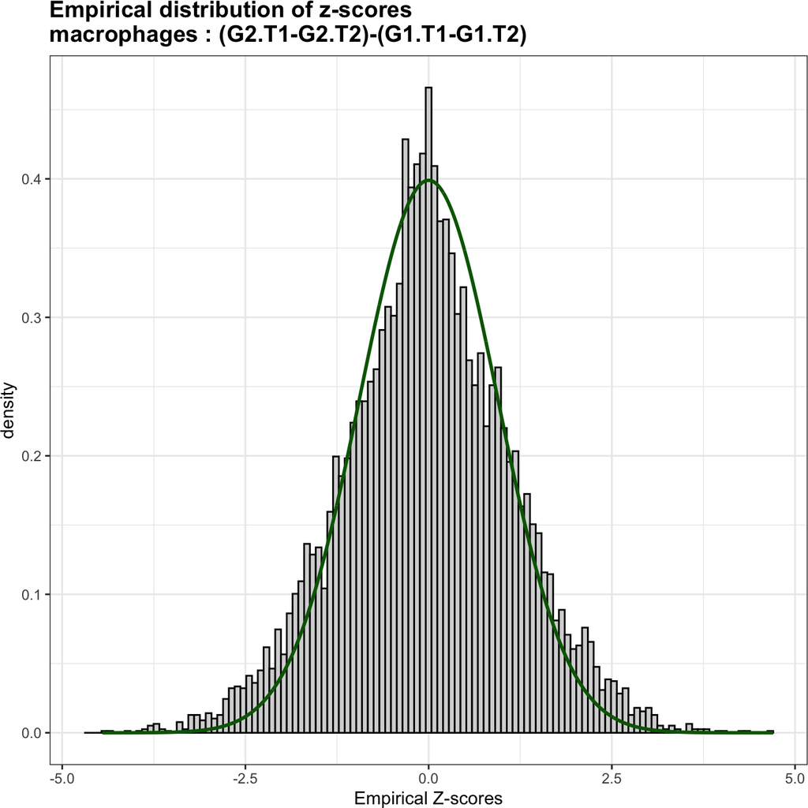

```r
DE_info_emp$z_distr_plots_emp_pval
## $`CD4T.(G1.T2-G1.T1)-(G2.T2-G2.T1)`
```

In general, these plots look OK. Therefore we will continue with these p-values.

*Ligand activity prediction: use the DE analysis output to predict the activity of ligands in receiver cell types and infer their potential target genes*

Here we get to the most complex part of this vignette.

Let’s look at the first contrasts of interest: `(G1.T2-G1.T1)-(G2.T2-G2.T1)`. A positive logFC value here means that the timepoint2-timepoint1 difference in group1 is bigger than in group2. This can be because the increase after therapy (resulting in higher G1.T2 values) is higher in group1 than in the group2. This is the type of trend we are looking for. However, a positive logFC will also be returned in case nothing happens in group1, and there is a therapy-associated decrease in group2. Or when the therapy-associated decrease in group2 is bigger than in group1. This latter examples are trends whe are not looking for. If we would just filter genes based on logFC to get a geneset of interest, we will confound this geneset with different patterns with different biological meanings.

To recap: we are interested in: * ligand-receptor interactions that increase after therapy more strongly in group1 vs group2 * target genes that follow the trend of their upstream ligand-receptor interactions and thus also increase after therapy more strongly in group1 vs group2.

How to get to these genesets: 1) Change the `celltype_de` table of DE results: * for the contrast (G1.T2-G1.T1)-(G2.T2-G2.T1): give all genes with a pos logFC value a value of 0 if their logFC in the **timepoint2-timepoint1** comparison (kept in `celltype_de_group1`) is smaller than (`logFC_threshold`). Give all genes with a negative logFC a value of 0. As a result, the geneset for ligand activity analysis will only contain genes that are increasing after therapy, and this increase in stronger in group1 than group2. * for the contrast (G2.T2-G2.T1)-(G1.T2-G1.T1): give all genes with a pos logFC value a value of 0 if their logFC in the **timepoint2-timepoint1** comparison (kept in `celltype_de_group2`) is smaller than (`logFC_threshold`). Give all genes with a negative logFC a value of 0. As a result, the geneset for ligand activity analysis will only contain genes that are increasing after therapy, and this increase in stronger in group2 than group1. * for the contrast (G1.T1-G1.T2)-(G2.T1-G2.T2): give all genes with a pos logFC value a value of 0 if their logFC in the **timepoint1-timepoint2** comparison (kept in `celltype_de_group1`) is smaller than (`logFC_threshold`). Give all genes with a negative logFC a value of 0. As a result, the geneset for ligand activity analysis will only contain genes that are decreasing after therapy, and this decrease in stronger in group1 than group1. * for the contrast (G2.T1-G2.T2)-(G1.T1-G1.T2): give all genes with a pos logFC value a value of 0 if their logFC in the **timepoint1-timepoint2** comparison (kept in `celltype_de_group2`) is smaller than (`logFC_threshold`). Give all genes with a negative logFC a value of 0. As a result, the geneset for ligand activity analysis will only contain genes that are decreasing after therapy, and this decrease in stronger in group2 than group1.

Because we want to keep the same patterns for the ligands/receptors: we will do the same but in more permissive setting: just make sure the On/timepoint2-vs-Pre/timepoint1 difference is in the expected direction without needing to be significant.

Gene-celltype table with genes that will keep their pos logFC value for contrast (G1.T2-G1.T1)-(G2.T2-G2.T1) + modified celltype_de table

```r
gene_celltype_tbl_increase_group1_permissive = celltype_de_group1 %>%
  filter(contrast == "G1.T2-G1.T1") %>%
  mutate(logFC_multiplier = ifelse(logFC > 0, 1, 0)) %>%
  distinct(gene, cluster_id, logFC_multiplier)

gene_celltype_tbl_increase_group1_stringent = celltype_de_group1 %>%
  filter(contrast == "G1.T2-G1.T1") %>%
  mutate(logFC_multiplier = ifelse(logFC >= logFC_threshold & p_val <= p_val_threshold, 1, 0)) %>%
  distinct(gene, cluster_id, logFC_multiplier)
```

```r
celltype_de_increase_group1_permissive = celltype_de %>%
  filter(contrast == "(G1.T2-G1.T1)-(G2.T2-G2.T1)") %>%
  inner_join(gene_celltype_tbl_increase_group1_permissive)

celltype_de_increase_group1_permissive = bind_rows(
  celltype_de_increase_group1_permissive %>%
    filter(logFC > 0) %>%
    mutate(logFC = logFC*logFC_multiplier),
  celltype_de_increase_group1_permissive %>%
    filter(logFC <= 0) %>%
    mutate(logFC = logFC*0)
) %>% arrange(-logFC)


celltype_de_increase_group1_stringent = celltype_de %>%
  filter(contrast == "(G1.T2-G1.T1)-(G2.T2-G2.T1)") %>%
  inner_join(gene_celltype_tbl_increase_group1_stringent)

celltype_de_increase_group1_stringent = bind_rows(
  celltype_de_increase_group1_stringent %>%
    filter(logFC > 0) %>%
    mutate(logFC = logFC*logFC_multiplier),
  celltype_de_increase_group1_stringent %>%
    filter(logFC <= 0) %>%
    mutate(logFC = logFC*0)
) %>% arrange(-logFC)


celltype_de_increase_group1_stringent %>% head()
## # A tibble: 6 × 10
##   gene     cluster_id  logFC logCPM     F p_adj.loc contrast                           p_val    p_adj logFC_multiplier
##   <chr>    <chr>       <dbl>  <dbl> <dbl>     <dbl> <chr>                              <dbl>    <dbl>            <dbl>
## 1 IGHV4.39 CD4T         5.15   4.17 14.7          1 (G1.T2-G1.T1)-(G2.T2-G2.T1) 0.0000000141 0.000122                1
## 2 CCL5     Fibroblast   2.85   6.33 10.4          1 (G1.T2-G1.T1)-(G2.T2-G2.T1) 0.0000652    0.0835                  1
## 3 HSPA1B   Fibroblast   2.47   6.46  7.64         1 (G1.T2-G1.T1)-(G2.T2-G2.T1) 0.000528     0.159                   1
## 4 IDO1     Fibroblast   2.36   5.45  4.97         1 (G1.T2-G1.T1)-(G2.T2-G2.T1) 0.00467      0.288                   1
## 5 BGN      macrophages  2.34   3.76  5.25         1 (G1.T2-G1.T1)-(G2.T2-G2.T1) 0.00176      0.234                   1
## 6 HSPA1A   Fibroblast   2.28   7.76  8.26         1 (G1.T2-G1.T1)-(G2.T2-G2.T1) 0.000325     0.128                   1
```

Gene-celltype table with genes that will keep their pos logFC value for contrast (G2.T2-G2.T1)-(G1.T2-G1.T1):

```r
gene_celltype_tbl_increase_group2_permissive = celltype_de_group2 %>%
  filter(contrast == "G2.T2-G2.T1") %>%
  mutate(logFC_multiplier = ifelse(logFC > 0, 1, 0)) %>%
  distinct(gene, cluster_id, logFC_multiplier)

gene_celltype_tbl_increase_group2_stringent = celltype_de_group2 %>%
  filter(contrast == "G2.T2-G2.T1") %>%
  mutate(logFC_multiplier = ifelse(logFC >= logFC_threshold & p_val <= p_val_threshold, 1, 0)) %>%
  distinct(gene, cluster_id, logFC_multiplier)
```

```r
celltype_de_increase_group2_permissive = celltype_de %>%
  filter(contrast == "(G2.T2-G2.T1)-(G1.T2-G1.T1)") %>%
  inner_join(gene_celltype_tbl_increase_group2_permissive)

celltype_de_increase_group2_permissive = bind_rows(
  celltype_de_increase_group2_permissive %>%
    filter(logFC > 0) %>%
    mutate(logFC = logFC*logFC_multiplier),
  celltype_de_increase_group2_permissive %>%
    filter(logFC <= 0) %>%
    mutate(logFC = logFC*0)
) %>% arrange(-logFC)

celltype_de_increase_group2_stringent = celltype_de %>%
  filter(contrast == "(G2.T2-G2.T1)-(G1.T2-G1.T1)") %>%
  inner_join(gene_celltype_tbl_increase_group2_stringent)

celltype_de_increase_group2_stringent = bind_rows(
  celltype_de_increase_group2_stringent %>%
    filter(logFC > 0) %>%
    mutate(logFC = logFC*logFC_multiplier),
  celltype_de_increase_group2_stringent %>%
    filter(logFC <= 0) %>%
    mutate(logFC = logFC*0)
) %>% arrange(-logFC)

celltype_de_increase_group2_stringent %>% head()
## # A tibble: 6 × 10
##   gene   cluster_id  logFC logCPM     F p_adj.loc contrast                          p_val   p_adj logFC_multiplier
##   <chr>  <chr>       <dbl>  <dbl> <dbl>     <dbl> <chr>                             <dbl>   <dbl>            <dbl>
## 1 FABP4  macrophages  5.17   6.54 11.5          1 (G2.T2-G2.T1)-(G1.T2-G1.T1) 0.0000189   0.0372                 1
## 2 CCL4L2 CD4T         3.69   6.22 12.2          1 (G2.T2-G2.T1)-(G1.T2-G1.T1) 0.000000471 0.00205                1
## 3 CFD    Fibroblast   2.87  10.6   3.64         1 (G2.T2-G2.T1)-(G1.T2-G1.T1) 0.0172      0.409                  1
## 4 PRSS23 macrophages  2.77   3.06  5.22         1 (G2.T2-G2.T1)-(G1.T2-G1.T1) 0.00345     0.263                  1
## 5 SAA1   Fibroblast   2.75   3.89  4.77         1 (G2.T2-G2.T1)-(G1.T2-G1.T1) 0.00650     0.321                  1
## 6 CCL3   CD4T         2.73   5.83  5.95         1 (G2.T2-G2.T1)-(G1.T2-G1.T1) 0.000353    0.0930                 1
```

Gene-celltype table with genes that will keep their pos logFC value for contrast (G1.T1-G1.T2)-(G2.T1-G2.T2):

```r
gene_celltype_tbl_decrease_group1_permissive = celltype_de_group1 %>%
  filter(contrast == "G1.T1-G1.T2") %>%
  mutate(logFC_multiplier = ifelse(logFC > 0, 1, 0)) %>%
  distinct(gene, cluster_id, logFC_multiplier)

gene_celltype_tbl_decrease_group1_stringent = celltype_de_group1 %>%
  filter(contrast == "G1.T1-G1.T2") %>%
  mutate(logFC_multiplier = ifelse(logFC >= logFC_threshold & p_val <= p_val_threshold, 1, 0)) %>%
  distinct(gene, cluster_id, logFC_multiplier)
```

```r
celltype_de_decrease_group1_permissive = celltype_de %>%
  filter(contrast == "(G1.T1-G1.T2)-(G2.T1-G2.T2)") %>%
  inner_join(gene_celltype_tbl_decrease_group1_permissive)

celltype_de_decrease_group1_permissive = bind_rows(
  celltype_de_decrease_group1_permissive %>%
    filter(logFC > 0) %>%
    mutate(logFC = logFC*logFC_multiplier),
  celltype_de_decrease_group1_permissive %>%
    filter(logFC <= 0) %>%
    mutate(logFC = logFC*0)
) %>% arrange(-logFC)

celltype_de_decrease_group1_stringent = celltype_de %>%
  filter(contrast == "(G1.T1-G1.T2)-(G2.T1-G2.T2)") %>%
  inner_join(gene_celltype_tbl_decrease_group1_stringent)

celltype_de_decrease_group1_stringent = bind_rows(
  celltype_de_decrease_group1_stringent %>%
    filter(logFC > 0) %>%
    mutate(logFC = logFC*logFC_multiplier),
  celltype_de_decrease_group1_stringent %>%
    filter(logFC <= 0) %>%
    mutate(logFC = logFC*0)
) %>% arrange(-logFC)

celltype_de_decrease_group1_stringent %>% head()
## # A tibble: 6 × 10
##   gene    cluster_id  logFC logCPM     F p_adj.loc contrast                         p_val  p_adj logFC_multiplier
##   <chr>   <chr>       <dbl>  <dbl> <dbl>     <dbl> <chr>                            <dbl>  <dbl>            <dbl>
## 1 IGLV3.1 Fibroblast   6.96   8.84 14.1          1 (G1.T1-G1.T2)-(G2.T1-G2.T2) 0.00000599 0.0566                1
## 2 HBB     macrophages  4.75   4.72  4.98         1 (G1.T1-G1.T2)-(G2.T1-G2.T2) 0.00430    0.283                 1
## 3 CALML5  CD4T         3.65   2.65  7.3          1 (G1.T1-G1.T2)-(G2.T1-G2.T2) 0.0000798  0.0489                1
## 4 HBB     CD4T         3.5    7.95  3.14         1 (G1.T1-G1.T2)-(G2.T1-G2.T2) 0.00932    0.326                 1
## 5 HBB     Fibroblast   3.48   8.17  1.69         1 (G1.T1-G1.T2)-(G2.T1-G2.T2) 0.103      0.671                 1
## 6 CCDC80  macrophages  3.04   3.11  7.74         1 (G1.T1-G1.T2)-(G2.T1-G2.T2) 0.000394   0.117                 1
```

Gene-celltype table with genes that will keep their pos logFC value for contrast (G2.T1-G2.T2)-(G1.T1-G1.T2):

```r
gene_celltype_tbl_decrease_group2_permissive = celltype_de_group2 %>%
  filter(contrast == "G2.T1-G2.T2") %>%
  mutate(logFC_multiplier = ifelse(logFC > 0, 1, 0)) %>%
  distinct(gene, cluster_id, logFC_multiplier)

gene_celltype_tbl_decrease_group2_stringent = celltype_de_group2 %>%
  filter(contrast == "G2.T1-G2.T2") %>%
  mutate(logFC_multiplier = ifelse(logFC >= logFC_threshold & p_val <= p_val_threshold, 1, 0)) %>%
  distinct(gene, cluster_id, logFC_multiplier)
```

```r
celltype_de_decrease_group2_permissive = celltype_de %>%
  filter(contrast == "(G2.T1-G2.T2)-(G1.T1-G1.T2)") %>%
  inner_join(gene_celltype_tbl_decrease_group2_permissive)

celltype_de_decrease_group2_permissive = bind_rows(
  celltype_de_decrease_group2_permissive %>%
    filter(logFC > 0) %>%
    mutate(logFC = logFC*logFC_multiplier),
  celltype_de_decrease_group2_permissive %>%
    filter(logFC <= 0) %>%
    mutate(logFC = logFC*0)
) %>% arrange(-logFC)

celltype_de_decrease_group2_stringent = celltype_de %>%
  filter(contrast == "(G2.T1-G2.T2)-(G1.T1-G1.T2)") %>%
  inner_join(gene_celltype_tbl_decrease_group2_stringent)

celltype_de_decrease_group2_stringent = bind_rows(
  celltype_de_decrease_group2_stringent %>%
    filter(logFC > 0) %>%
    mutate(logFC = logFC*logFC_multiplier),
  celltype_de_decrease_group2_stringent %>%
    filter(logFC <= 0) %>%
    mutate(logFC = logFC*0)
) %>% arrange(-logFC)

celltype_de_decrease_group2_stringent %>% head()
## # A tibble: 6 × 10
##   gene     cluster_id  logFC logCPM     F p_adj.loc contrast                           p_val    p_adj logFC_multiplier
##   <chr>    <chr>       <dbl>  <dbl> <dbl>     <dbl> <chr>                              <dbl>    <dbl>            <dbl>
## 1 IGHV4.39 CD4T         5.15   4.17 14.7          1 (G2.T1-G2.T2)-(G1.T1-G1.T2) 0.0000000141 0.000122                1
## 2 IGHV3.23 macrophages  4.67   5.31  7.78         1 (G2.T1-G2.T2)-(G1.T1-G1.T2) 0.000177     0.0916                  1
## 3 IGLV3.25 macrophages  4.29   4.08  8            1 (G2.T1-G2.T2)-(G1.T1-G1.T2) 0.000146     0.0916                  1
## 4 IGLV3.21 Fibroblast   4.24   4.16  8.45         1 (G2.T1-G2.T2)-(G1.T1-G1.T2) 0.000281     0.128                   1
## 5 IGKV3.20 macrophages  3.21   6.15  5.58         1 (G2.T1-G2.T2)-(G1.T1-G1.T2) 0.00130      0.223                   1
## 6 FDCSP    Fibroblast   3.2    4.27  5.07         1 (G2.T1-G2.T2)-(G1.T1-G1.T2) 0.00430      0.284                   1
```

So let’s now make the new `cellype_de` tables:

The permissive table that will be used for the prioritization of ligand-receptor pairs based on DE values:

```r
celltype_de_LR = list(
  celltype_de_increase_group1_permissive,
  celltype_de_increase_group2_permissive,
  celltype_de_decrease_group1_permissive,
  celltype_de_decrease_group2_permissive) %>% bind_rows()
```

The stringent table that will be used for the creation of genesets for the ligand activity analysis:

```r
celltype_de_genesets = list(
  celltype_de_increase_group1_stringent,
  celltype_de_increase_group2_stringent,
  celltype_de_decrease_group1_stringent,
  celltype_de_decrease_group2_stringent) %>% bind_rows()
```

We will first inspect the geneset_oi-vs-background ratios for the default tresholds:

```r
geneset_assessment = contrast_tbl$contrast %>%
  lapply(
    process_geneset_data,
    celltype_de_genesets, logFC_threshold, p_val_adj, p_val_threshold
  ) %>%
  bind_rows()
geneset_assessment
## # A tibble: 12 × 12
##    cluster_id  n_background n_geneset_up n_geneset_down prop_geneset_up prop_geneset_down in_range_up in_range_down contrast                    logFC_threshold p_val_threshold adjusted
##    <chr>              <int>        <int>          <int>           <dbl>             <dbl> <lgl>       <lgl>         <chr>                                 <dbl>           <dbl> <lgl>
##  1 CD4T                8701           22              0         0.00253                 0 FALSE       FALSE         (G1.T2-G1.T1)-(G2.T2-G2.T1)             0.5            0.05 FALSE
##  2 Fibroblast         10255          133              0         0.0130                  0 TRUE        FALSE         (G1.T2-G1.T1)-(G2.T2-G2.T1)             0.5            0.05 FALSE
##  3 macrophages         9833           96              0         0.00976                 0 TRUE        FALSE         (G1.T2-G1.T1)-(G2.T2-G2.T1)             0.5            0.05 FALSE
##  4 CD4T                8701           50              0         0.00575                 0 TRUE        FALSE         (G2.T2-G2.T1)-(G1.T2-G1.T1)             0.5            0.05 FALSE
##  5 Fibroblast         10255           27              0         0.00263                 0 FALSE       FALSE         (G2.T2-G2.T1)-(G1.T2-G1.T1)             0.5            0.05 FALSE
##  6 macrophages         9833           68              0         0.00692                 0 TRUE        FALSE         (G2.T2-G2.T1)-(G1.T2-G1.T1)             0.5            0.05 FALSE
##  7 CD4T                8701           34              0         0.00391                 0 FALSE       FALSE         (G1.T1-G1.T2)-(G2.T1-G2.T2)             0.5            0.05 FALSE
##  8 Fibroblast         10255          144              0         0.0140                  0 TRUE        FALSE         (G1.T1-G1.T2)-(G2.T1-G2.T2)             0.5            0.05 FALSE
##  9 macrophages         9833           90              0         0.00915                 0 TRUE        FALSE         (G1.T1-G1.T2)-(G2.T1-G2.T2)             0.5            0.05 FALSE
## 10 CD4T                8701           60              0         0.00690                 0 TRUE        FALSE         (G2.T1-G2.T2)-(G1.T1-G1.T2)             0.5            0.05 FALSE
## 11 Fibroblast         10255           23              0         0.00224                 0 FALSE       FALSE         (G2.T1-G2.T2)-(G1.T1-G1.T2)             0.5            0.05 FALSE
## 12 macrophages         9833           67              0         0.00681                 0 TRUE        FALSE         (G2.T1-G2.T2)-(G1.T1-G1.T2)             0.5            0.05 FALSE
```

We can see here that for most geneset/background ratio’s we are within or close to the recommended range for the upregulated genes (`in_range_up` and `in_range_down` columns). This is not the case for the downregulated genes, but we are not interested in those for now.

```r
ligand_activities_targets_DEgenes = suppressMessages(suppressWarnings(
  get_ligand_activities_targets_DEgenes(
    receiver_de = celltype_de_genesets,
    receivers_oi = intersect(receivers_oi, celltype_de_genesets$cluster_id %>% unique()),
    ligand_target_matrix = ligand_target_matrix,
    logFC_threshold = logFC_threshold,
    p_val_threshold = p_val_threshold,
    p_val_adj = p_val_adj,
    top_n_target = top_n_target,
    verbose = TRUE,
    n.cores = n.cores
  )
))
```

*Combine DE information for ligand-senders and receptors-receivers*

Use the adapted `celltype_de_LR` table to keep the expression change patterns we want:

```r
sender_receiver_de = combine_sender_receiver_de(
  sender_de = celltype_de_LR,
  receiver_de = celltype_de_LR,
  senders_oi = senders_oi,
  receivers_oi = receivers_oi,
  lr_network = lr_network
)
```

```r
sender_receiver_de %>% head(20)
## # A tibble: 20 × 12
##    contrast                    sender      receiver    ligand receptor lfc_ligand lfc_receptor ligand_receptor_lfc_avg p_val_ligand p_adj_ligand p_val_receptor p_adj_receptor
##    <chr>                       <chr>       <chr>       <chr>  <chr>         <dbl>        <dbl>                   <dbl>        <dbl>        <dbl>          <dbl>          <dbl>
##  1 (G2.T2-G2.T1)-(G1.T2-G1.T1) Fibroblast  CD4T        PIP    NPTN           4.36       0.35                      2.36  0.00641          0.321          0.161            0.747
##  2 (G1.T1-G1.T2)-(G2.T1-G2.T2) Fibroblast  CD4T        PIP    NPTN           4.36       0.35                      2.36  0.00641          0.321          0.161            0.747
##  3 (G2.T2-G2.T1)-(G1.T2-G1.T1) Fibroblast  macrophages PIP    NPTN           4.36       0.141                     2.25  0.00641          0.321          0.650            0.994
##  4 (G2.T2-G2.T1)-(G1.T2-G1.T1) Fibroblast  Fibroblast  PIP    NPTN           4.36       0.114                     2.24  0.00641          0.321          0.708            1.00
##  5 (G1.T1-G1.T2)-(G2.T1-G2.T2) Fibroblast  Fibroblast  PIP    NPTN           4.36       0.114                     2.24  0.00641          0.321          0.708            1.00
##  6 (G1.T1-G1.T2)-(G2.T1-G2.T2) Fibroblast  Fibroblast  PIP    CD4            4.36       0.0732                    2.22  0.00641          0.321          0.924            1.00
##  7 (G2.T2-G2.T1)-(G1.T2-G1.T1) Fibroblast  Fibroblast  PIP    CD4            4.36       0                         2.18  0.00641          0.321          0.924            1.00
##  8 (G2.T2-G2.T1)-(G1.T2-G1.T1) Fibroblast  CD4T        PIP    CD4            4.36       0                         2.18  0.00641          0.321          0.868            0.999
##  9 (G2.T2-G2.T1)-(G1.T2-G1.T1) Fibroblast  macrophages PIP    CD4            4.36       0                         2.18  0.00641          0.321          0.0793           0.637
## 10 (G1.T1-G1.T2)-(G2.T1-G2.T2) Fibroblast  CD4T        PIP    CD4            4.36       0                         2.18  0.00641          0.321          0.868            0.999
## 11 (G1.T1-G1.T2)-(G2.T1-G2.T2) Fibroblast  macrophages PIP    CD4            4.36       0                         2.18  0.00641          0.321          0.0793           0.637
## 12 (G1.T1-G1.T2)-(G2.T1-G2.T2) Fibroblast  macrophages PIP    NPTN           4.36       0                         2.18  0.00641          0.321          0.650            0.994
## 13 (G2.T2-G2.T1)-(G1.T2-G1.T1) CD4T        CD4T        CCL4L2 CCR1           3.69       0.516                     2.10  0.000000471      0.00205        0.421            0.924
## 14 (G1.T1-G1.T2)-(G2.T1-G2.T2) CD4T        CD4T        CCL4L2 CCR1           3.69       0.516                     2.10  0.000000471      0.00205        0.421            0.924
## 15 (G1.T2-G1.T1)-(G2.T2-G2.T1) Fibroblast  Fibroblast  CDH2   CDH2           1.98       1.98                      1.98  0.00251          0.255          0.00251          0.255
## 16 (G2.T1-G2.T2)-(G1.T1-G1.T2) Fibroblast  Fibroblast  CDH2   CDH2           1.98       1.98                      1.98  0.00251          0.255          0.00251          0.255
## 17 (G2.T2-G2.T1)-(G1.T2-G1.T1) macrophages CD4T        PIP    NPTN           3.58       0.35                      1.96  0.00195          0.240          0.161            0.747
## 18 (G1.T1-G1.T2)-(G2.T1-G2.T2) macrophages CD4T        PIP    NPTN           3.58       0.35                      1.96  0.00195          0.240          0.161            0.747
## 19 (G1.T2-G1.T1)-(G2.T2-G2.T1) CD4T        Fibroblast  CXCL14 CXCR4          2.63       1.28                      1.96  0.000546         0.111          0.0565           0.569
## 20 (G2.T1-G2.T2)-(G1.T1-G1.T2) CD4T        Fibroblast  CXCL14 CXCR4          2.63       1.28                      1.96  0.000546         0.111          0.0565           0.569
```

*Prioritization: rank cell-cell communication patterns through multi-criteria prioritization*

```r
sender_receiver_tbl = sender_receiver_de %>% distinct(sender, receiver)

metadata_combined = SummarizedExperiment::colData(sce) %>% tibble::as_tibble()

if(!is.na(batches)){
  grouping_tbl = metadata_combined[,c(sample_id, group_id, batches)] %>%
    tibble::as_tibble() %>% distinct()
  colnames(grouping_tbl) = c("sample","group",batches)
} else {
  grouping_tbl = metadata_combined[,c(sample_id, group_id)] %>%
    tibble::as_tibble() %>% distinct()
  colnames(grouping_tbl) = c("sample","group")
}

prioritization_tables = suppressMessages(generate_prioritization_tables(
    sender_receiver_info = abundance_expression_info$sender_receiver_info,
    sender_receiver_de = sender_receiver_de,
    ligand_activities_targets_DEgenes = ligand_activities_targets_DEgenes,
    contrast_tbl = contrast_tbl,
    sender_receiver_tbl = sender_receiver_tbl,
    grouping_tbl = grouping_tbl,
    scenario = "regular", # all prioritization criteria will be weighted equally
    fraction_cutoff = fraction_cutoff,
    abundance_data_receiver = abundance_expression_info$abundance_data_receiver,
    abundance_data_sender = abundance_expression_info$abundance_data_sender,
    ligand_activity_down = FALSE
  ))
```

*Compile the MultiNicheNet output object*

```r
multinichenet_output = list(
    celltype_info = abundance_expression_info$celltype_info,
    celltype_de = celltype_de_genesets,
    sender_receiver_info = abundance_expression_info$sender_receiver_info,
    sender_receiver_de =  sender_receiver_de,
    ligand_activities_targets_DEgenes = ligand_activities_targets_DEgenes,
    prioritization_tables = prioritization_tables,
    grouping_tbl = grouping_tbl,
    lr_target_prior_cor = tibble()
  )
multinichenet_output = make_lite_output(multinichenet_output)
```